# Data Cleaning

```python
import sqlite3
conn = sqlite3.connect('lending-club-loan-data/database.sqlite')
c = conn.cursor()
```

```python
import pandas as pd
import numpy as np

pd.set_option('display.max_columns', 80)
pd.set_option('display.max_rows', 80)
## only select rows that are fully funded and are individual loans (no joint loans)
data=pd.read_sql('''
SELECT *
FROM loan
WHERE funded_amnt==loan_amnt AND (application_type LIKE '%INDIVIDUAL%') AND term LIKE '%36 months%'
''',conn)
```

```python
data.drop(['index'],axis=1)
```

|  | id | member_id | loan_amnt | funded_amnt | funded_amnt_inv | term | int_rate | installment | grade | sub_grade | emp_title | emp_length | home_ownership | annual_inc | verification_status | issue_d | loan_status | pymnt_plan | url | desc | purpose | title | zip_code | addr_state | dti | delinq_2yrs | earliest_cr_line | inq_last_6mths | mths_since_last_delinq | … |
| --- | --- | --- | --- | --- | --- | --- | --- | --- | --- | --- | --- | --- | --- | --- | --- | --- | --- | --- | --- | --- | --- | --- | --- | --- | --- | --- | --- | --- | --- | --- |
| 0 | 1077501 | 1296599.0 | 5000.0 | 5000.0 | 4975.0 | 36 months | 10.65% | 162.87 | B | B2 | None | 10+ years | RENT | 24000.00 | Verified | Dec-2011 | Fully Paid | n | https://www.lendingclub.com/browse/loanDetail.... | Borrower added on 12/22/11 > I need to upgra... | credit_card | Computer | 860xx | AZ | 27.65 | 0.0 | Jan-1985 | 1.0 | NaN | … |
| 1 | 1077175 | 1313524.0 | 2400.0 | 2400.0 | 2400.0 | 36 months | 15.96% | 84.33 | C | C5 | None | 10+ years | RENT | 12252.00 | Not Verified | Dec-2011 | Fully Paid | n | https://www.lendingclub.com/browse/loanDetail.... | None | small_business | real estate business | 606xx | IL | 8.72 | 0.0 | Nov-2001 | 2.0 | NaN | … |
| 2 | 1076863 | 1277178.0 | 10000.0 | 10000.0 | 10000.0 | 36 months | 13.49% | 339.31 | C | C1 | AIR RESOURCES BOARD | 10+ years | RENT | 49200.00 | Source Verified | Dec-2011 | Fully Paid | n | https://www.lendingclub.com/browse/loanDetail.... | Borrower added on 12/21/11 > to pay for prop... | other | personel | 917xx | CA | 20.00 | 0.0 | Feb-1996 | 1.0 | 35.0 | … |
| 3 | 1075269 | 1311441.0 | 5000.0 | 5000.0 | 5000.0 | 36 months | 7.90% | 156.46 | A | A4 | Veolia Transportaton | 3 years | RENT | 36000.00 | Source Verified | Dec-2011 | Fully Paid | n | https://www.lendingclub.com/browse/loanDetail.... | None | wedding | My wedding loan I promise to pay back | 852xx | AZ | 11.20 | 0.0 | Nov-2004 | 3.0 | NaN | … |
| 4 | 1072053 | 1288686.0 | 3000.0 | 3000.0 | 3000.0 | 36 months | 18.64% | 109.43 | E | E1 | MKC Accounting | 9 years | RENT | 48000.00 | Source Verified | Dec-2011 | Fully Paid | n | https://www.lendingclub.com/browse/loanDetail.... | Borrower added on 12/16/11 > Downpayment for... | car | Car Downpayment | 900xx | CA | 5.35 | 0.0 | Jan-2007 | 2.0 | NaN | … |
| 5 | 1069908 | 1305008.0 | 12000.0 | 12000.0 | 12000.0 | 36 months | 12.69% | 402.54 | B | B5 | UCLA | 10+ years | OWN | 75000.00 | Source Verified | Dec-2011 | Fully Paid | n | https://www.lendingclub.com/browse/loanDetail.... | None | debt_consolidation | Consolidation | 913xx | CA | 10.78 | 0.0 | Oct-1989 | 0.0 | NaN | … |
| 6 | 1064687 | 1298717.0 | 9000.0 | 9000.0 | 9000.0 | 36 months | 13.49% | 305.38 | C | C1 | Va. Dept of Conservation/Recreation | < 1 year | RENT | 30000.00 | Source Verified | Dec-2011 | Charged Off | n | https://www.lendingclub.com/browse/loanDetail.... | Borrower added on 12/15/11 > Plan to pay off... | debt_consolidation | freedom | 245xx | VA | 10.08 | 0.0 | Apr-2004 | 1.0 | NaN | … |
| 7 | 1069866 | 1304956.0 | 3000.0 | 3000.0 | 3000.0 | 36 months | 9.91% | 96.68 | B | B1 | Target | 3 years | RENT | 15000.00 | Source Verified | Dec-2011 | Fully Paid | n | https://www.lendingclub.com/browse/loanDetail.... | Borrower added on 12/19/11 > I intend to pay... | credit_card | citicard fund | 606xx | IL | 12.56 | 0.0 | Jul-2003 | 2.0 | NaN | … |
| 8 | 1069057 | 1303503.0 | 10000.0 | 10000.0 | 10000.0 | 36 months | 10.65% | 325.74 | B | B2 | SFMTA | 3 years | RENT | 100000.00 | Source Verified | Dec-2011 | Charged Off | n | https://www.lendingclub.com/browse/loanDetail.... | None | other | Other Loan | 951xx | CA | 7.06 | 0.0 | May-1991 | 2.0 | NaN | … |
| 9 | 1069759 | 1304871.0 | 1000.0 | 1000.0 | 1000.0 | 36 months | 16.29% | 35.31 | D | D1 | Internal revenue Service | < 1 year | RENT | 28000.00 | Not Verified | Dec-2011 | Fully Paid | n | https://www.lendingclub.com/browse/loanDetail.... | None | debt_consolidation | Debt Consolidation Loan | 641xx | MO | 20.31 | 0.0 | Sep-2007 | 1.0 | NaN | … |
| 10 | 1065775 | 1299699.0 | 10000.0 | 10000.0 | 10000.0 | 36 months | 15.27% | 347.98 | C | C4 | Chin's Restaurant | 4 years | RENT | 42000.00 | Not Verified | Dec-2011 | Fully Paid | n | https://www.lendingclub.com/browse/loanDetail.... | None | home_improvement | Home | 921xx | CA | 18.60 | 0.0 | Oct-1998 | 2.0 | 61.0 | … |
| 11 | 1069971 | 1304884.0 | 3600.0 | 3600.0 | 3600.0 | 36 months | 6.03% | 109.57 | A | A1 | Duracell | 10+ years | MORTGAGE | 110000.00 | Not Verified | Dec-2011 | Fully Paid | n | https://www.lendingclub.com/browse/loanDetail.... | Borrower added on 12/15/11 > Payoff other le... | major_purchase | Holiday | 067xx | CT | 10.52 | 0.0 | Aug-1993 | 0.0 | NaN | … |
| 12 | 1062474 | 1294539.0 | 6000.0 | 6000.0 | 6000.0 | 36 months | 11.71% | 198.46 | B | B3 | Connection Inspection | 1 year | MORTGAGE | 84000.00 | Verified | Dec-2011 | Fully Paid | n | https://www.lendingclub.com/browse/loanDetail.... | Borrower added on 12/16/11 > This is a loan ... | medical | Medical | 890xx | UT | 18.44 | 2.0 | Oct-2003 | 0.0 | 8.0 | … |
| 13 | 1069742 | 1304855.0 | 9200.0 | 9200.0 | 9200.0 | 36 months | 6.03% | 280.01 | A | A1 | Network Interpreting Service | 6 years | RENT | 77385.19 | Not Verified | Dec-2011 | Fully Paid | n | https://www.lendingclub.com/browse/loanDetail.... | None | debt_consolidation | lowerratemeanseasiertogetoutofdebt! | 921xx | CA | 9.86 | 0.0 | Jan-2001 | 0.0 | NaN | … |
| 14 | 1039153 | 1269083.0 | 21000.0 | 21000.0 | 21000.0 | 36 months | 12.42% | 701.73 | B | B4 | Osram Sylvania | 10+ years | RENT | 105000.00 | Verified | Dec-2011 | Charged Off | n | https://www.lendingclub.com/browse/loanDetail.... | Borrower added on 12/16/11 > Decided to clea... | debt_consolidation | Debt Cleanup | 335xx | FL | 13.22 | 0.0 | Feb-1983 | 0.0 | NaN | … |
| 15 | 1069710 | 1304821.0 | 10000.0 | 10000.0 | 10000.0 | 36 months | 11.71% | 330.76 | B | B3 | Value Air | 10+ years | OWN | 50000.00 | Source Verified | Dec-2011 | Fully Paid | n | https://www.lendingclub.com/browse/loanDetail.... | Borrower added on 12/17/11 > Have a stable j... | credit_card | Credit Card Loan | 799xx | TX | 11.18 | 0.0 | Jul-1985 | 0.0 | NaN | … |
| 16 | 1069700 | 1304810.0 | 10000.0 | 10000.0 | 10000.0 | 36 months | 11.71% | 330.76 | B | B3 | Wells Fargo Bank | 5 years | RENT | 50000.00 | Not Verified | Dec-2011 | Fully Paid | n | https://www.lendingclub.com/browse/loanDetail.... | None | debt_consolidation | Debt Consolidation | 917xx | CA | 16.01 | 0.0 | Apr-2003 | 0.0 | NaN | … |
| 17 | 1069559 | 1304634.0 | 6000.0 | 6000.0 | 6000.0 | 36 months | 11.71% | 198.46 | B | B3 | bmg-educational | 1 year | RENT | 76000.00 | Not Verified | Dec-2011 | Charged Off | n | https://www.lendingclub.com/browse/loanDetail.... | None | major_purchase | cash | 900xx | CA | 2.40 | 0.0 | Jun-2001 | 1.0 | NaN | … |
| 18 | 1069697 | 1273773.0 | 15000.0 | 15000.0 | 15000.0 | 36 months | 9.91% | 483.38 | B | B1 | Winfield Pathology Consultants | 2 years | MORTGAGE | 92000.00 | Verified | Dec-2011 | Fully Paid | n | https://www.lendingclub.com/browse/loanDetail.... | None | credit_card | No more credit card debt! | 605xx | IL | 29.44 | 0.0 | Feb-2002 | 0.0 | NaN | … |
| 19 | 1069800 | 1304679.0 | 15000.0 | 15000.0 | 8725.0 | 36 months | 14.27% | 514.64 | C | C2 | nyc transit | 9 years | RENT | 60000.00 | Not Verified | Dec-2011 | Charged Off | n | https://www.lendingclub.com/browse/loanDetail.... | Borrower added on 12/15/11 > looking to cons... | debt_consolidation | consolidation | 103xx | NY | 15.22 | 0.0 | Oct-2003 | 1.0 | NaN | … |
| 20 | 1069799 | 1304678.0 | 4000.0 | 4000.0 | 4000.0 | 36 months | 11.71% | 132.31 | B | B3 | Shands Hospital at the University of Fl | 10+ years | MORTGAGE | 106000.00 | Not Verified | Dec-2011 | Fully Paid | n | https://www.lendingclub.com/browse/loanDetail.... | None | debt_consolidation | Debt Consolidation | 326xx | FL | 5.63 | 1.0 | Aug-1984 | 0.0 | 18.0 | … |
| 21 | 1047704 | 1278806.0 | 8500.0 | 8500.0 | 8500.0 | 36 months | 11.71% | 281.15 | B | B3 | Oakridge homes | < 1 year | RENT | 25000.00 | Source Verified | Dec-2011 | Fully Paid | n | https://www.lendingclub.com/browse/loanDetail.... | Borrower added on 12/15/11 > My loan is for ... | credit_card | Credit card repayment loan | 564xx | MN | 12.19 | 0.0 | Nov-2006 | 0.0 | NaN | … |
| 22 | 1032111 | 1261745.0 | 4375.0 | 4375.0 | 4375.0 | 36 months | 7.51% | 136.11 | A | A3 | None | 7 years | MORTGAGE | 17108.00 | Source Verified | Dec-2011 | Fully Paid | n | https://www.lendingclub.com/browse/loanDetail.... | Borrower added on 12/17/11 > This loan is a ... | debt_consolidation | Debt Consolidation | 141xx | NY | 20.34 | 0.0 | Dec-1987 | 0.0 | NaN | … |
| 23 | 1069539 | 1304608.0 | 31825.0 | 31825.0 | 31825.0 | 36 months | 7.90% | 995.82 | A | A4 | Audubon Mutual Housing Corporation | 5 years | MORTGAGE | 75000.00 | Verified | Dec-2011 | Fully Paid | n | https://www.lendingclub.com/browse/loanDetail.... | Borrower added on 12/15/11 > Hello<br>I plan... | debt_consolidation | Debt Consolidation Loan | 080xx | NJ | 14.03 | 0.0 | Nov-1981 | 0.0 | NaN | … |
| 24 | 1069591 | 1304289.0 | 5000.0 | 5000.0 | 5000.0 | 36 months | 8.90% | 158.77 | A | A5 | Good Samaritan Society | 2 years | RENT | 24044.00 | Verified | Dec-2011 | Fully Paid | n | https://www.lendingclub.com/browse/loanDetail.... | Borrower added on 12/16/11 > The purpose of ... | debt_consolidation | Consolidation | 974xx | OR | 11.93 | 0.0 | Apr-2005 | 0.0 | 45.0 | … |
| 25 | 1069530 | 1291365.0 | 7000.0 | 7000.0 | 7000.0 | 36 months | 15.96% | 245.97 | C | C5 | GREG BARRETT DRYWALL | 7 years | RENT | 34000.00 | Source Verified | Dec-2011 | Fully Paid | n | https://www.lendingclub.com/browse/loanDetail.... | None | credit_card | Credit Card Loan | 934xx | CA | 6.35 | 0.0 | Oct-2007 | 1.0 | NaN | … |
| 26 | 1069522 | 1304589.0 | 12400.0 | 12400.0 | 12400.0 | 36 months | 10.65% | 403.91 | B | B2 | Sharp Lawn Inc. | 10+ years | RENT | 41000.00 | Not Verified | Dec-2011 | Fully Paid | n | https://www.lendingclub.com/browse/loanDetail.... | Borrower added on 12/16/11 > I plan to use t... | credit_card | December 2011 Credit Card Loan | 405xx | KY | 11.80 | 0.0 | Jul-2005 | 2.0 | NaN | … |
| 27 | 1069361 | 1304255.0 | 10800.0 | 10800.0 | 10800.0 | 36 months | 9.91% | 348.03 | B | B1 | Department of Justice | 2 years | RENT | 55596.00 | Source Verified | Dec-2011 | Fully Paid | n | https://www.lendingclub.com/browse/loanDetail.... | Borrower added on 12/19/11 > I have a very s... | moving | Moving to better job; help a veteran! | 946xx | CA | 5.50 | 0.0 | Dec-2000 | 0.0 | NaN | … |
| 28 | 1069357 | 1304251.0 | 15000.0 | 15000.0 | 15000.0 | 36 months | 7.90% | 469.36 | A | A4 | Gateway Hospice | 1 year | RENT | 45000.00 | Verified | Dec-2011 | Fully Paid | n | https://www.lendingclub.com/browse/loanDetail.... | Borrower added on 12/15/11 > I am looking to... | debt_consolidation | Debt Consolidation Loan | 445xx | OH | 8.48 | 0.0 | Nov-2004 | 0.0 | NaN | … |
| 29 | 1069356 | 1304250.0 | 6000.0 | 6000.0 | 6000.0 | 36 months | 12.42% | 200.50 | B | B4 | Cox Communications | 1 year | RENT | 36852.00 | Source Verified | Dec-2011 | Fully Paid | n | https://www.lendingclub.com/browse/loanDetail.... | Borrower added on 12/15/11 > This loan will ... | debt_consolidation | Credit Card Consolidation | 850xx | AZ | 10.62 | 0.0 | Apr-2007 | 1.0 | NaN | … |

[output cut: 51 more lines]

620015 rows × 74 columns

```python
data.columns.values
```

```
array(['index', 'id', 'member_id', 'loan_amnt', 'funded_amnt',
       'funded_amnt_inv', 'term', 'int_rate', 'installment', 'grade',
       'sub_grade', 'emp_title', 'emp_length', 'home_ownership',
       'annual_inc', 'verification_status', 'issue_d', 'loan_status',
       'pymnt_plan', 'url', 'desc', 'purpose', 'title', 'zip_code',
       'addr_state', 'dti', 'delinq_2yrs', 'earliest_cr_line',
       'inq_last_6mths', 'mths_since_last_delinq',
       'mths_since_last_record', 'open_acc', 'pub_rec', 'revol_bal',
       'revol_util', 'total_acc', 'initial_list_status', 'out_prncp',
       'out_prncp_inv', 'total_pymnt', 'total_pymnt_inv',
       'total_rec_prncp', 'total_rec_int', 'total_rec_late_fee',
       'recoveries', 'collection_recovery_fee', 'last_pymnt_d',
       'last_pymnt_amnt', 'next_pymnt_d', 'last_credit_pull_d',
       'collections_12_mths_ex_med', 'mths_since_last_major_derog',
       'policy_code', 'application_type', 'annual_inc_joint', 'dti_joint',
       'verification_status_joint', 'acc_now_delinq', 'tot_coll_amt',
       'tot_cur_bal', 'open_acc_6m', 'open_il_6m', 'open_il_12m',
       'open_il_24m', 'mths_since_rcnt_il', 'total_bal_il', 'il_util',
       'open_rv_12m', 'open_rv_24m', 'max_bal_bc', 'all_util',
       'total_rev_hi_lim', 'inq_fi', 'total_cu_tl', 'inq_last_12m'], dtype=object)
```

```python
feat_raw=pd.DataFrame
memberinfo=['id','loan_amnt','term','int_rate','installment','sub_grade','emp_title', 'emp_length', 'home_ownership',
       'annual_inc','loan_status','purpose',
       'addr_state', 'dti', 'delinq_2yrs', 'earliest_cr_line',
       'inq_last_6mths', 'mths_since_last_delinq',
       'mths_since_last_record', 'open_acc', 'pub_rec', 'revol_bal',
       'revol_util', 'total_acc','total_pymnt','total_rec_prncp','total_rec_int', 'total_rec_late_fee',
       'recoveries', 'collection_recovery_fee', 'last_pymnt_d',
       'last_pymnt_amnt', 'next_pymnt_d','collections_12_mths_ex_med', 'mths_since_last_major_derog']
feat_raw=data[memberinfo].copy()
```

```python
feat_raw.dtypes
```

```
id                              object
loan_amnt                      float64
term                            object
int_rate                        object
installment                    float64
sub_grade                       object
emp_title                       object
emp_length                      object
home_ownership                  object
annual_inc                     float64
loan_status                     object
purpose                         object
addr_state                      object
dti                            float64
delinq_2yrs                    float64
earliest_cr_line                object
inq_last_6mths                 float64
mths_since_last_delinq         float64
mths_since_last_record         float64
open_acc                       float64
pub_rec                        float64
revol_bal                      float64
revol_util                      object
total_acc                      float64
total_pymnt                    float64
total_rec_prncp                float64
total_rec_int                  float64
total_rec_late_fee             float64
recoveries                     float64
collection_recovery_fee        float64
last_pymnt_d                    object
last_pymnt_amnt                float64
next_pymnt_d                    object
collections_12_mths_ex_med     float64
mths_since_last_major_derog    float64
dtype: object
```

## Look for nulls in the data

```python
feat_raw.isnull().sum()
```

```
id                                  0
loan_amnt                           0
term                                0
int_rate                            0
installment                         0
sub_grade                           0
emp_title                       41496
emp_length                          0
home_ownership                      0
annual_inc                          4
loan_status                         0
purpose                             0
addr_state                          0
dti                                 0
delinq_2yrs                        28
earliest_cr_line                   28
inq_last_6mths                     28
mths_since_last_delinq         316869
mths_since_last_record         519656
open_acc                           28
pub_rec                            28
revol_bal                           0
revol_util                        384
total_acc                          28
total_pymnt                         0
total_rec_prncp                     0
total_rec_int                       0
total_rec_late_fee                  0
recoveries                          0
collection_recovery_fee             0
last_pymnt_d                    12222
last_pymnt_amnt                     0
next_pymnt_d                   195889
collections_12_mths_ex_med        140
mths_since_last_major_derog    461992
dtype: int64
```

```python
feat_raw.annual_inc.fillna(0,inplace=True)
feat_raw.revol_bal.fillna(0,inplace=True)
feat_raw.collections_12_mths_ex_med.fillna(0,inplace=True)
feat_raw.isnull().sum()
```

```
id                                  0
loan_amnt                           0
term                                0
int_rate                            0
installment                         0
sub_grade                           0
emp_title                       41496
emp_length                          0
home_ownership                      0
annual_inc                          0
loan_status                         0
purpose                             0
addr_state                          0
dti                                 0
delinq_2yrs                        28
earliest_cr_line                   28
inq_last_6mths                     28
mths_since_last_delinq         316869
mths_since_last_record         519656
open_acc                           28
pub_rec                            28
revol_bal                           0
revol_util                        384
total_acc                          28
total_pymnt                         0
total_rec_prncp                     0
total_rec_int                       0
total_rec_late_fee                  0
recoveries                          0
collection_recovery_fee             0
last_pymnt_d                    12222
last_pymnt_amnt                     0
next_pymnt_d                   195889
collections_12_mths_ex_med          0
mths_since_last_major_derog    461992
dtype: int64
```

28 shows up a lot, I suspect they are the same 28 loans with many suspicious NaNs. I shall inspect.

## Inspect the curious 28 nans

```python
feat_raw.query('total_acc != total_acc')
```

|  | id | loan_amnt | term | int_rate | installment | sub_grade | emp_title | emp_length | home_ownership | annual_inc | loan_status | purpose | addr_state | dti | delinq_2yrs | earliest_cr_line | inq_last_6mths | mths_since_last_delinq | mths_since_last_record | open_acc | pub_rec | revol_bal | revol_util | total_acc | total_pymnt | total_rec_prncp | total_rec_int | total_rec_late_fee | recoveries | … |
| --- | --- | --- | --- | --- | --- | --- | --- | --- | --- | --- | --- | --- | --- | --- | --- | --- | --- | --- | --- | --- | --- | --- | --- | --- | --- | --- | --- | --- | --- | --- |
| 30603 | 79967 | 5000.0 | 36 months | 7.43% | 155.38 | A2 | None | < 1 year | NONE | 0.0 | Does not meet the credit policy. Status:Fully ... | other | NY | 1.00 | NaN | None | NaN | NaN | NaN | NaN | NaN | 0.0 | None | NaN | 5593.46 | 5000.00 | 593.46 | 0.000000 | 0.00 | … |
| 30604 | 79924 | 7000.0 | 36 months | 7.75% | 218.55 | A3 | None | < 1 year | NONE | 0.0 | Does not meet the credit policy. Status:Fully ... | other | NY | 1.00 | NaN | None | NaN | NaN | NaN | NaN | NaN | 0.0 | None | NaN | 7867.53 | 7000.00 | 867.53 | 0.000000 | 0.00 | … |
| 30613 | 71823 | 4350.0 | 36 months | 8.07% | 136.45 | A4 | None | < 1 year | RENT | 120000.0 | Does not meet the credit policy. Status:Fully ... | other | MA | 4.00 | NaN | None | NaN | NaN | NaN | NaN | NaN | 0.0 | None | NaN | 4911.68 | 4350.00 | 561.68 | 0.000000 | 0.00 | … |
| 30624 | 72197 | 3900.0 | 36 months | 9.33% | 124.62 | B3 | None | < 1 year | RENT | 98000.0 | Does not meet the credit policy. Status:Fully ... | other | NY | 10.00 | NaN | None | NaN | NaN | NaN | NaN | NaN | 0.0 | None | NaN | 4485.99 | 3900.00 | 585.99 | 0.000000 | 0.00 | … |
| 30632 | 79893 | 6700.0 | 36 months | 7.75% | 209.18 | A3 | None | < 1 year | NONE | 0.0 | Does not meet the credit policy. Status:Fully ... | other | NY | 1.00 | NaN | None | NaN | NaN | NaN | NaN | NaN | 0.0 | None | NaN | 7530.42 | 6700.00 | 830.42 | 0.000000 | 0.00 | … |
| 30635 | 73003 | 3200.0 | 36 months | 9.96% | 103.20 | B5 | None | < 1 year | MORTGAGE | 150000.0 | Does not meet the credit policy. Status:Fully ... | other | MA | 10.00 | NaN | None | NaN | NaN | NaN | NaN | NaN | 0.0 | None | NaN | 3590.53 | 3200.00 | 390.53 | 0.000000 | 0.00 | … |
| 30658 | 91023 | 1900.0 | 36 months | 9.64% | 61.00 | B4 | Scheduall | 1 year | MORTGAGE | 100000.0 | Does not meet the credit policy. Status:Fully ... | debt_consolidation | FL | 10.00 | NaN | None | NaN | NaN | NaN | NaN | NaN | 0.0 | None | NaN | 1999.12 | 1900.00 | 99.12 | 0.000000 | 0.00 | … |
| 30663 | 85961 | 1200.0 | 36 months | 9.01% | 38.17 | B2 | Classic Components | < 1 year | RENT | 36000.0 | Does not meet the credit policy. Status:Fully ... | other | TX | 3.27 | NaN | None | NaN | NaN | NaN | NaN | NaN | 0.0 | None | NaN | 1373.88 | 1200.00 | 173.88 | 0.000000 | 0.00 | … |
| 30664 | 85818 | 5000.0 | 36 months | 11.22% | 164.23 | C4 | Compensation Solutions | < 1 year | RENT | 28000.0 | Does not meet the credit policy. Status:Fully ... | other | NJ | 3.51 | NaN | None | NaN | NaN | NaN | NaN | NaN | 0.0 | None | NaN | 5858.35 | 5000.00 | 828.36 | 29.994759 | 0.00 | … |
| 30665 | 85781 | 1400.0 | 36 months | 10.91% | 45.78 | C3 | Stanford University Libraries, LOCKSS Project | < 1 year | RENT | 40000.0 | Does not meet the credit policy. Status:Fully ... | other | MO | 8.61 | NaN | None | NaN | NaN | NaN | NaN | NaN | 0.0 | None | NaN | 1663.04 | 1400.00 | 248.05 | 14.994369 | 0.00 | … |
| 30666 | 85675 | 1000.0 | 36 months | 14.07% | 34.21 | E3 | Macy's | 10+ years | RENT | 25000.0 | Does not meet the credit policy. Status:Fully ... | other | NJ | 16.27 | NaN | None | NaN | NaN | NaN | NaN | NaN | 0.0 | None | NaN | 1231.38 | 1000.00 | 231.38 | 0.000000 | 0.00 | … |
| 30667 | 84670 | 5000.0 | 36 months | 7.75% | 156.11 | A3 | Diamond Management and Technology Consultants | 10+ years | MORTGAGE | 300000.0 | Does not meet the credit policy. Status:Fully ... | other | LA | 5.38 | NaN | None | NaN | NaN | NaN | NaN | NaN | 0.0 | None | NaN | 5565.65 | 5000.00 | 565.65 | 0.000000 | 0.00 | … |
| 30668 | 84098 | 2500.0 | 36 months | 7.43% | 77.69 | A2 | U.S. Bank | 9 years | MORTGAGE | 66624.0 | Does not meet the credit policy. Status:Fully ... | other | OH | 10.36 | NaN | None | NaN | NaN | NaN | NaN | NaN | 0.0 | None | NaN | 2600.23 | 2500.00 | 100.23 | 0.000000 | 0.00 | … |
| 30669 | 83979 | 3000.0 | 36 months | 7.43% | 93.23 | A2 | NC | 1 year | MORTGAGE | 80000.0 | Does not meet the credit policy. Status:Fully ... | other | NJ | 0.39 | NaN | None | NaN | NaN | NaN | NaN | NaN | 0.0 | None | NaN | 3120.26 | 3000.00 | 120.26 | 0.000000 | 0.00 | … |
| 30670 | 83489 | 2600.0 | 36 months | 8.38% | 81.94 | A5 | College Pro Painters | 3 years | MORTGAGE | 6500.0 | Does not meet the credit policy. Status:Charge... | other | CO | 6.46 | NaN | None | NaN | NaN | NaN | NaN | NaN | 0.0 | None | NaN | 2342.01 | 1962.69 | 329.05 | 21.640000 | 28.63 | … |
| 30671 | 83185 | 1000.0 | 36 months | 7.12% | 30.94 | A1 | Mana Products | 6 years | RENT | 50000.0 | Does not meet the credit policy. Status:Fully ... | other | NY | 1.10 | NaN | None | NaN | NaN | NaN | NaN | NaN | 0.0 | None | NaN | 1113.35 | 1000.00 | 113.35 | 0.000000 | 0.00 | … |
| 30672 | 76629 | 1275.0 | 36 months | 12.49% | 42.65 | D3 | Infinitely law group | 1 year | RENT | 40000.0 | Does not meet the credit policy. Status:Charge... | other | MA | 10.00 | NaN | None | NaN | NaN | NaN | NaN | NaN | 0.0 | None | NaN | 1341.96 | 340.50 | 128.57 | 0.000000 | 872.89 | … |
| 30673 | 74014 | 6450.0 | 36 months | 11.22% | 211.85 | C4 | Apto Solutions | 2 years | RENT | 32000.0 | Does not meet the credit policy. Status:Fully ... | other | GA | 10.00 | NaN | None | NaN | NaN | NaN | NaN | NaN | 0.0 | None | NaN | 7798.60 | 6450.00 | 1228.60 | 120.000000 | 0.00 | … |
| 30674 | 81085 | 10500.0 | 36 months | 11.22% | 344.87 | C4 | Town of Plainville | 3 years | RENT | 60000.0 | Does not meet the credit policy. Status:Fully ... | other | CT | 19.50 | NaN | None | NaN | NaN | NaN | NaN | NaN | 0.0 | None | NaN | 11219.80 | 10500.00 | 719.80 | 0.000000 | 0.00 | … |
| 30675 | 77792 | 3000.0 | 36 months | 9.01% | 95.42 | B2 | Tanks Tavern | < 1 year | RENT | 35000.0 | Does not meet the credit policy. Status:Fully ... | other | KS | 10.00 | NaN | None | NaN | NaN | NaN | NaN | NaN | 0.0 | None | NaN | 3434.97 | 3000.00 | 434.97 | 0.000000 | 0.00 | … |
| 30676 | 77757 | 3000.0 | 36 months | 9.33% | 95.86 | B3 | None | < 1 year | OWN | 20000.0 | Does not meet the credit policy. Status:Fully ... | other | MA | 10.00 | NaN | None | NaN | NaN | NaN | NaN | NaN | 0.0 | None | NaN | 3450.79 | 3000.00 | 450.79 | 0.000000 | 0.00 | … |
| 30677 | 74505 | 2000.0 | 36 months | 9.96% | 64.50 | B5 | None | < 1 year | RENT | 6000.0 | Does not meet the credit policy. Status:Fully ... | other | FL | 10.00 | NaN | None | NaN | NaN | NaN | NaN | NaN | 0.0 | None | NaN | 2322.36 | 2000.00 | 322.36 | 0.000000 | 0.00 | … |
| 30678 | 74323 | 6500.0 | 36 months | 9.64% | 208.66 | B4 | Air Force | < 1 year | RENT | 20000.0 | Does not meet the credit policy. Status:Charge... | other | CT | 10.00 | NaN | None | NaN | NaN | NaN | NaN | NaN | 0.0 | None | NaN | 7193.05 | 1791.32 | 503.81 | 0.000000 | 4897.92 | … |
| 30679 | 73582 | 3500.0 | 36 months | 10.28% | 113.39 | C1 | None | < 1 year | RENT | 180000.0 | Does not meet the credit policy. Status:Fully ... | other | NY | 10.00 | NaN | None | NaN | NaN | NaN | NaN | NaN | 0.0 | None | NaN | 3719.34 | 3500.00 | 219.34 | 0.000000 | 0.00 | … |
| 30680 | 72998 | 1000.0 | 36 months | 9.64% | 32.11 | B4 | Halping hands company inc. | < 1 year | RENT | 12000.0 | Does not meet the credit policy. Status:Fully ... | other | MA | 10.00 | NaN | None | NaN | NaN | NaN | NaN | NaN | 0.0 | None | NaN | 1155.53 | 1000.00 | 155.53 | 0.000000 | 0.00 | … |
| 30681 | 72176 | 2525.0 | 36 months | 9.33% | 80.69 | B3 | None | < 1 year | RENT | 110000.0 | Does not meet the credit policy. Status:Fully ... | other | NY | 10.00 | NaN | None | NaN | NaN | NaN | NaN | NaN | 0.0 | None | NaN | 2904.30 | 2525.00 | 379.30 | 0.000000 | 0.00 | … |
| 30682 | 71623 | 6500.0 | 36 months | 8.38% | 204.84 | A5 | None | < 1 year | NONE | 0.0 | Does not meet the credit policy. Status:Fully ... | other | NY | 4.00 | NaN | None | NaN | NaN | NaN | NaN | NaN | 0.0 | None | NaN | 7373.83 | 6500.00 | 873.83 | 0.000000 | 0.00 | … |
| 30683 | 70686 | 5000.0 | 36 months | 7.75% | 156.11 | A3 | Homemaker | 10+ years | MORTGAGE | 70000.0 | Does not meet the credit policy. Status:Fully ... | other | CT | 8.81 | NaN | None | NaN | NaN | NaN | NaN | NaN | 0.0 | None | NaN | 5619.72 | 5000.00 | 619.72 | 0.000000 | 0.00 | … |

Most interestingly, they all have a status "Does not meet the credit policy". Lets look into that, as that is not an expected value.

```python
grp = feat_raw.groupby('loan_status')
grp.describe()
```

| loan_status |  | annual_inc | collection_recovery_fee | collections_12_mths_ex_med | delinq_2yrs | dti | inq_last_6mths | installment | last_pymnt_amnt | loan_amnt | mths_since_last_delinq | mths_since_last_major_derog | mths_since_last_record | open_acc | pub_rec | recoveries | revol_bal | total_acc | total_pymnt | total_rec_int | total_rec_late_fee | total_rec_prncp |
| --- | --- | --- | --- | --- | --- | --- | --- | --- | --- | --- | --- | --- | --- | --- | --- | --- | --- | --- | --- | --- | --- | --- |
| Charged Off | count | 2.899900e+04 | 28999.000000 | 28999.000000 | 28999.000000 | 28999.000000 | 28999.000000 | 28999.000000 | 28999.000000 | 28999.000000 | 13009.000000 | 5787.000000 | 3787.000000 | 28999.000000 | 28999.000000 | 28999.000000 | 2.899900e+04 | 28999.000000 | 28999.000000 | 28999.000000 | 28999.000000 | 28999.000000 |
|  | mean | 6.115969e+04 | 69.970545 | 0.007828 | 0.280423 | 18.104272 | 0.969792 | 403.473397 | 414.051346 | 11692.973896 | 34.237682 | 42.807327 | 76.785582 | 10.741784 | 0.153005 | 641.675609 | 1.347438e+04 | 23.084831 | 5584.689552 | 1408.531769 | 2.512973 | 3531.969198 |
|  | std | 6.455718e+04 | 225.409847 | 0.092334 | 0.802859 | 7.997711 | 1.117541 | 257.209008 | 515.120271 | 7347.473781 | 21.968352 | 21.744058 | 30.621205 | 4.847813 | 0.467737 | 1218.739994 | 1.755516e+04 | 11.351386 | 4970.646087 | 1326.085256 | 10.213291 | 3487.942848 |
|  | min | 4.080000e+03 | 0.000000 | 0.000000 | 0.000000 | 0.000000 | 0.000000 | 29.160000 | 0.000000 | 900.000000 | 0.000000 | 0.000000 | 0.000000 | 0.000000 | 0.000000 | 0.000000 | 0.000000e+00 | 2.000000 | 0.000000 | 0.000000 | 0.000000 | 0.000000 |
|  | 25% | 3.700000e+04 | 0.000000 | 0.000000 | 0.000000 | 12.160000 | 0.000000 | 218.130000 | 201.270000 | 6250.000000 | 15.000000 | 25.000000 | 56.000000 | 7.000000 | 0.000000 | 0.000000 | 5.580500e+03 | 15.000000 | 2113.830000 | 516.760000 | 0.000000 | 1130.910000 |
|  | 50% | 5.130000e+04 | 0.700000 | 0.000000 | 0.000000 | 18.010000 | 1.000000 | 341.670000 | 334.730000 | 10000.000000 | 31.000000 | 42.000000 | 84.000000 | 10.000000 | 0.000000 | 26.330000 | 9.973000e+03 | 21.000000 | 4184.390000 | 1038.920000 | 0.000000 | 2477.890000 |
|  | 75% | 7.300000e+04 | 17.289700 | 0.000000 | 0.000000 | 23.890000 | 2.000000 | 522.260000 | 518.340000 | 15000.000000 | 50.000000 | 60.000000 | 102.000000 | 13.000000 | 0.000000 | 896.930000 | 1.689300e+04 | 30.000000 | 7486.415000 | 1870.905000 | 0.000000 | 4762.535000 |
|  | max | 8.706582e+06 | 7002.190000 | 2.000000 | 18.000000 | 39.910000 | 8.000000 | 1424.570000 | 34833.350000 | 35000.000000 | 152.000000 | 152.000000 | 129.000000 | 45.000000 | 12.000000 | 31900.520000 | 1.746716e+06 | 110.000000 | 43935.130000 | 16602.700000 | 294.680000 | 34483.270000 |
| Current | count | 4.026380e+05 | 402638.000000 | 402638.000000 | 402638.000000 | 402638.000000 | 402638.000000 | 402638.000000 | 402638.000000 | 402638.000000 | 204779.000000 | 115041.000000 | 70787.000000 | 402638.000000 | 402638.000000 | 402638.000000 | 4.026380e+05 | 402638.000000 | 402638.000000 | 402638.000000 | 402638.000000 | 402638.000000 |
|  | mean | 7.367112e+04 | 0.000000 | 0.018739 | 0.342807 | 18.130677 | 0.608971 | 421.692001 | 425.935786 | 12809.665941 | 33.824499 | 44.393529 | 68.205108 | 11.488650 | 0.232000 | 0.000000 | 1.619940e+04 | 24.531892 | 4802.878939 | 1099.982654 | 0.137521 | 3702.758763 |
|  | std | 6.754683e+04 | 0.000000 | 0.155801 | 0.912100 | 8.367540 | 0.906854 | 262.806130 | 375.301486 | 7953.401301 | 21.824649 | 22.402884 | 27.006649 | 5.381903 | 0.670157 | 0.000000 | 2.335230e+04 | 11.780115 | 5230.559377 | 1207.551753 | 2.300606 | 4145.316809 |
|  | min | 3.000000e+03 | 0.000000 | 0.000000 | 0.000000 | 0.000000 | 0.000000 | 30.120000 | 0.000000 | 1000.000000 | 0.000000 | 0.000000 | 0.000000 | 0.000000 | 0.000000 | 0.000000 | 0.000000e+00 | 2.000000 | 0.000000 | 0.000000 | 0.000000 | 0.000000 |
|  | 25% | 4.300000e+04 | 0.000000 | 0.000000 | 0.000000 | 11.780000 | 0.000000 | 225.840000 | 220.050000 | 7000.000000 | 15.000000 | 27.000000 | 50.000000 | 8.000000 | 0.000000 | 0.000000 | 5.989000e+03 | 16.000000 | 1231.792500 | 297.100000 | 0.000000 | 903.230000 |
|  | 50% | 6.100000e+04 | 0.000000 | 0.000000 | 0.000000 | 17.570000 | 0.000000 | 346.395000 | 344.950000 | 10000.000000 | 30.000000 | 44.000000 | 67.000000 | 11.000000 | 0.000000 | 0.000000 | 1.091500e+04 | 23.000000 | 3035.005000 | 714.610000 | 0.000000 | 2269.110000 |
|  | 75% | 8.911925e+04 | 0.000000 | 0.000000 | 0.000000 | 24.060000 | 1.000000 | 561.430000 | 561.590000 | 17000.000000 | 49.000000 | 62.000000 | 87.000000 | 14.000000 | 0.000000 | 0.000000 | 1.936600e+04 | 31.000000 | 6500.780000 | 1480.620000 | 0.000000 | 4969.150000 |
|  | max | 9.000000e+06 | 0.000000 | 20.000000 | 30.000000 | 39.990000 | 6.000000 | 1445.460000 | 35330.490000 | 35000.000000 | 188.000000 | 188.000000 | 121.000000 | 84.000000 | 86.000000 | 0.000000 | 2.904836e+06 | 169.000000 | 46757.530000 | 14828.710000 | 229.750000 | 34998.170000 |
| Default | count | 7.150000e+02 | 715.000000 | 715.000000 | 715.000000 | 715.000000 | 715.000000 | 715.000000 | 715.000000 | 715.000000 | 345.000000 | 202.000000 | 131.000000 | 715.000000 | 715.000000 | 715.000000 | 7.150000e+02 | 715.000000 | 715.000000 | 715.000000 | 715.000000 | 715.000000 |
|  | mean | 6.228154e+04 | 0.000000 | 0.019580 | 0.401399 | 19.504517 | 0.871329 | 414.011301 | 430.149650 | 12019.860140 | 33.072464 | 43.613861 | 73.175573 | 11.496503 | 0.223776 | 0.000000 | 1.383329e+04 | 24.254545 | 5503.680307 | 1533.111301 | 1.772264 | 3968.796755 |
|  | std | 5.963224e+04 | 0.000000 | 0.138650 | 1.099910 | 8.298499 | 1.114057 | 255.480159 | 357.752037 | 7362.857281 | 21.618198 | 23.100675 | 24.960116 | 5.064118 | 0.545154 | 0.000000 | 2.060174e+04 | 12.225569 | 5433.390650 | 1449.510053 | 7.877050 | 4081.943163 |
|  | min | 9.300000e+03 | 0.000000 | 0.000000 | 0.000000 | 0.380000 | 0.000000 | 33.210000 | 0.000000 | 1000.000000 | 1.000000 | 1.000000 | 6.000000 | 1.000000 | 0.000000 | 0.000000 | 0.000000e+00 | 4.000000 | 0.000000 | 0.000000 | 0.000000 | 0.000000 |
|  | 25% | 3.625000e+04 | 0.000000 | 0.000000 | 0.000000 | 13.440000 | 0.000000 | 221.535000 | 230.560000 | 6400.000000 | 14.000000 | 25.000000 | 56.000000 | 8.000000 | 0.000000 | 0.000000 | 5.237000e+03 | 15.000000 | 1959.820000 | 569.105000 | 0.000000 | 1363.630000 |
|  | 50% | 5.100000e+04 | 0.000000 | 0.000000 | 0.000000 | 19.380000 | 1.000000 | 352.680000 | 356.480000 | 10000.000000 | 29.000000 | 45.000000 | 74.000000 | 11.000000 | 0.000000 | 0.000000 | 9.951000e+03 | 22.000000 | 3828.910000 | 1084.200000 | 0.000000 | 2701.970000 |
|  | 75% | 7.431300e+04 | 0.000000 | 0.000000 | 0.000000 | 25.470000 | 1.000000 | 528.100000 | 537.050000 | 15000.000000 | 50.000000 | 60.000000 | 90.500000 | 14.000000 | 0.000000 | 0.000000 | 1.681600e+04 | 32.000000 | 7217.480000 | 2008.335000 | 0.000000 | 5174.080000 |
|  | max | 1.300000e+06 | 0.000000 | 1.000000 | 11.000000 | 39.720000 | 6.000000 | 1300.200000 | 6960.700000 | 35000.000000 | 81.000000 | 136.000000 | 119.000000 | 33.000000 | 5.000000 | 0.000000 | 4.037950e+05 | 82.000000 | 36811.500000 | 10535.570000 | 75.880000 | 27965.700000 |
| Does not meet the credit policy. Status:Charged Off | count | 6.170000e+02 | 617.000000 | 617.000000 | 614.000000 | 617.000000 | 614.000000 | 617.000000 | 617.000000 | 617.000000 | 389.000000 | 0.000000 | 263.000000 | 614.000000 | 614.000000 | 617.000000 | 6.170000e+02 | 614.000000 | 617.000000 | 617.000000 | 617.000000 | 617.000000 |
|  | mean | 6.959296e+04 | 109.749899 | 0.000000 | 0.214984 | 14.173306 | 4.644951 | 318.750016 | 302.882658 | 9249.230146 | 24.033419 | NaN | 23.292776 | 9.824104 | 0.118893 | 510.027901 | 2.946914e+04 | 21.355049 | 4650.194465 | 1179.285689 | 5.577041 | 2955.303890 |
|  | std | 6.377857e+04 | 474.209101 | 0.000000 | 0.617343 | 7.384483 | 3.541089 | 223.680466 | 318.749388 | 6412.413167 | 24.821661 | NaN | 40.194017 | 5.690638 | 0.333846 | 1771.524145 | 7.480266e+04 | 13.895708 | 4660.345010 | 1158.693545 | 15.034675 | 3060.022036 |
|  | min | 2.000000e+03 | 0.000000 | 0.000000 | 0.000000 | 0.000000 | 0.000000 | 15.910000 | 0.000000 | 500.000000 | 0.000000 | NaN | 0.000000 | 1.000000 | 0.000000 | 0.000000 | 0.000000e+00 | 1.000000 | 0.000000 | 0.000000 | 0.000000 | 0.000000 |
|  | 25% | 3.600000e+04 | 0.000000 | 0.000000 | 0.000000 | 8.720000 | 3.000000 | 163.490000 | 118.730000 | 4800.000000 | 0.000000 | NaN | 0.000000 | 6.000000 | 0.000000 | 0.000000 | 2.486000e+03 | 10.000000 | 1501.190000 | 370.740000 | 0.000000 | 836.190000 |
|  | 50% | 5.200000e+04 | 1.170000 | 0.000000 | 0.000000 | 14.700000 | 4.000000 | 256.790000 | 215.000000 | 7500.000000 | 17.000000 | NaN | 0.000000 | 9.000000 | 0.000000 | 73.810000 | 7.331000e+03 | 19.000000 | 3147.360000 | 836.070000 | 0.000000 | 1997.210000 |
|  | 75% | 7.800000e+04 | 4.580000 | 0.000000 | 0.000000 | 19.730000 | 6.000000 | 412.350000 | 388.270000 | 12000.000000 | 43.000000 | NaN | 46.500000 | 13.000000 | 0.000000 | 292.960000 | 2.109300e+04 | 29.000000 | 6321.720000 | 1563.100000 | 0.000000 | 4067.370000 |
|  | max | 7.000000e+05 | 5192.990000 | 0.000000 | 6.000000 | 29.960000 | 33.000000 | 926.830000 | 4500.510000 | 25000.000000 | 80.000000 | NaN | 117.000000 | 47.000000 | 2.000000 | 27750.000000 | 1.207359e+06 | 63.000000 | 39473.920000 | 6900.580000 | 143.093045 | 19401.130000 |
| Does not meet the credit policy. Status:Fully Paid | count | 1.717000e+03 | 1717.000000 | 1717.000000 | 1692.000000 | 1717.000000 | 1692.000000 | 1717.000000 | 1717.000000 | 1717.000000 | 962.000000 | 0.000000 | 531.000000 | 1692.000000 | 1692.000000 | 1717.000000 | 1.717000e+03 | 1692.000000 | 1717.000000 | 1717.000000 | 1717.000000 | 1717.000000 |
|  | mean | 7.159994e+04 | 0.000000 | 0.000000 | 0.244090 | 13.986913 | 3.963948 | 294.105381 | 1991.360239 | 8587.099592 | 26.454262 | NaN | 19.822976 | 10.008865 | 0.089835 | 0.000000 | 2.845734e+04 | 22.229314 | 10268.593261 | 1678.519825 | 2.974816 | 8587.098626 |
|  | std | 7.424415e+04 | 0.000000 | 0.000000 | 0.799242 | 7.526867 | 3.066656 | 209.706436 | 3551.871313 | 6032.265276 | 24.012971 | NaN | 37.142189 | 5.664317 | 0.337263 | 0.000000 | 6.028200e+04 | 14.152064 | 7306.445628 | 1458.220730 | 12.234702 | 6032.264626 |
|  | min | 0.000000e+00 | 0.000000 | 0.000000 | 0.000000 | 0.000000 | 0.000000 | 15.670000 | 0.000000 | 500.000000 | 0.000000 | NaN | 0.000000 | 1.000000 | 0.000000 | 0.000000 | 0.000000e+00 | 1.000000 | 503.540000 | 3.540000 | 0.000000 | 500.000000 |
|  | 25% | 3.650000e+04 | 0.000000 | 0.000000 | 0.000000 | 7.880000 | 2.000000 | 136.460000 | 160.430000 | 4000.000000 | 1.000000 | NaN | 0.000000 | 6.000000 | 0.000000 | 0.000000 | 2.470000e+03 | 11.000000 | 4857.590000 | 627.450000 | 0.000000 | 4000.000000 |
|  | 50% | 5.500000e+04 | 0.000000 | 0.000000 | 0.000000 | 14.310000 | 4.000000 | 238.530000 | 420.050000 | 7000.000000 | 22.000000 | NaN | 0.000000 | 9.000000 | 0.000000 | 0.000000 | 8.086000e+03 | 20.000000 | 8229.690000 | 1228.600000 | 0.000000 | 7000.000000 |
|  | 75% | 8.400000e+04 | 0.000000 | 0.000000 | 0.000000 | 20.000000 | 5.000000 | 399.780000 | 2146.650000 | 12000.000000 | 44.000000 | NaN | 7.500000 | 13.000000 | 0.000000 | 0.000000 | 2.247000e+04 | 31.000000 | 13947.140000 | 2212.140000 | 0.000000 | 12000.000000 |
|  | max | 1.440000e+06 | 0.000000 | 0.000000 | 13.000000 | 29.950000 | 31.000000 | 940.140000 | 25207.530000 | 25000.000000 | 83.000000 | NaN | 118.000000 | 38.000000 | 5.000000 | 0.000000 | 9.520130e+05 | 73.000000 | 33845.240000 | 8845.250000 | 208.819530 | 25000.010000 |
| Fully Paid | count | 1.668900e+05 | 166890.000000 | 166890.000000 | 166890.000000 | 166890.000000 | 166890.000000 | 166890.000000 | 166890.000000 | 166890.000000 | 73734.000000 | 31294.000000 | 21384.000000 | 166890.000000 | 166890.000000 | 166890.000000 | 1.668900e+05 | 166890.000000 | 166890.000000 | 166890.000000 | 166890.000000 | 166890.000000 |
|  | mean | 7.202174e+04 | 0.000000 | 0.006208 | 0.243256 | 15.930496 | 0.805908 | 395.264270 | 6049.661770 | 11824.835371 | 35.523015 | 43.675944 | 74.522353 | 10.745503 | 0.146264 | 0.000000 | 1.435865e+04 | 24.616963 | 13334.193880 | 1524.542976 | 0.347689 | 11809.303221 |
|  | std | 6.023799e+04 | 0.000000 | 0.086875 | 0.737969 | 7.697108 | 1.035872 | 248.521937 | 6053.308882 | 7343.973399 | 21.705506 | 21.570651 | 29.889767 | 4.829532 | 0.439646 | 0.000000 | 1.837212e+04 | 11.694342 | 8382.611237 | 1439.705312 | 3.654011 | 7344.010192 |
|  | min | 3.000000e+03 | 0.000000 | 0.000000 | 0.000000 | 0.000000 | 0.000000 | 15.690000 | 0.000000 | 500.000000 | 0.000000 | 0.000000 | 0.000000 | 0.000000 | 0.000000 | 0.000000 | 0.000000e+00 | 2.000000 | 0.000000 | 0.000000 | 0.000000 | 0.000000 |
|  | 25% | 4.400000e+04 | 0.000000 | 0.000000 | 0.000000 | 10.180000 | 0.000000 | 211.125000 | 989.182500 | 6250.000000 | 17.000000 | 27.000000 | 54.000000 | 7.000000 | 0.000000 | 0.000000 | 5.457000e+03 | 16.000000 | 7137.025000 | 555.110000 | 0.000000 | 6250.000000 |
|  | 50% | 6.099600e+04 | 0.000000 | 0.000000 | 0.000000 | 15.510000 | 0.000000 | 337.190000 | 4586.035000 | 10000.000000 | 33.000000 | 43.000000 | 76.000000 | 10.000000 | 0.000000 | 0.000000 | 1.015700e+04 | 23.000000 | 11411.575000 | 1125.435000 | 0.000000 | 10000.000000 |
|  | 75% | 8.600000e+04 | 0.000000 | 0.000000 | 0.000000 | 21.300000 | 1.000000 | 513.800000 | 8801.900000 | 15000.000000 | 51.000000 | 60.000000 | 101.000000 | 13.000000 | 0.000000 | 0.000000 | 1.780800e+04 | 31.000000 | 17415.120000 | 2038.570000 | 0.000000 | 15000.000000 |
|  | max | 7.141778e+06 | 0.000000 | 6.000000 | 29.000000 | 39.990000 | 8.000000 | 1409.990000 | 36188.840000 | 35000.000000 | 151.000000 | 159.000000 | 121.000000 | 58.000000 | 15.000000 | 0.000000 | 1.743266e+06 | 150.000000 | 49978.687781 | 14978.690000 | 286.747566 | 35000.020000 |
| In Grace Period | count | 3.974000e+03 | 3974.000000 | 3974.000000 | 3974.000000 | 3974.000000 | 3974.000000 | 3974.000000 | 3974.000000 | 3974.000000 | 2202.000000 | 1251.000000 | 697.000000 | 3974.000000 | 3974.000000 | 3974.000000 | 3.974000e+03 | 3974.000000 | 3974.000000 | 3974.000000 | 3974.000000 | 3974.000000 |
|  | mean | 7.486149e+04 | 0.000000 | 0.018369 | 0.458228 | 18.942589 | 0.787116 | 450.440458 | 495.445591 | 13233.618520 | 31.156222 | 44.007994 | 66.875179 | 11.509814 | 0.234776 | 0.000000 | 1.454559e+04 | 24.531454 | 6190.133998 | 1592.669799 | 2.579261 | 4594.884935 |
|  | std | 1.543129e+05 | 0.000000 | 0.137997 | 1.059822 | 8.447717 | 1.029627 | 276.693788 | 762.069207 | 8079.892180 | 21.348371 | 22.036296 | 26.627435 | 5.445590 | 0.620960 | 0.000000 | 1.796554e+04 | 12.219875 | 6104.177842 | 1529.100905 | 11.180137 | 4742.021294 |
|  | min | 7.680000e+03 | 0.000000 | 0.000000 | 0.000000 | 0.000000 | 0.000000 | 31.650000 | 0.000000 | 1000.000000 | 0.000000 | 1.000000 | 5.000000 | 2.000000 | 0.000000 | 0.000000 | 0.000000e+00 | 2.000000 | 0.000000 | 0.000000 | 0.000000 | 0.000000 |
|  | 25% | 4.200000e+04 | 0.000000 | 0.000000 | 0.000000 | 12.692500 | 0.000000 | 251.522500 | 242.630000 | 7300.000000 | 13.000000 | 26.000000 | 50.000000 | 8.000000 | 0.000000 | 0.000000 | 5.418250e+03 | 15.000000 | 1842.857500 | 512.240000 | 0.000000 | 1276.705000 |
|  | 50% | 6.000000e+04 | 0.000000 | 0.000000 | 0.000000 | 18.665000 | 0.000000 | 373.145000 | 375.460000 | 11000.000000 | 27.000000 | 44.000000 | 68.000000 | 10.000000 | 0.000000 | 0.000000 | 1.013600e+04 | 23.000000 | 4312.320000 | 1165.420000 | 0.000000 | 3075.900000 |
|  | 75% | 8.524125e+04 | 0.000000 | 0.000000 | 1.000000 | 24.907500 | 1.000000 | 590.620000 | 599.995000 | 17600.000000 | 46.000000 | 61.000000 | 85.000000 | 14.000000 | 0.000000 | 0.000000 | 1.762775e+04 | 32.000000 | 8680.272500 | 2201.632500 | 0.000000 | 6413.185000 |
|  | max | 8.900060e+06 | 0.000000 | 2.000000 | 13.000000 | 39.890000 | 6.000000 | 1374.630000 | 20944.280000 | 35000.000000 | 83.000000 | 137.000000 | 119.000000 | 46.000000 | 7.000000 | 0.000000 | 2.998990e+05 | 112.000000 | 44062.890000 | 12350.760000 | 191.840000 | 34761.450000 |
| Issued | count | 5.956000e+03 | 5956.000000 | 5956.000000 | 5956.000000 | 5956.000000 | 5956.000000 | 5956.000000 | 5956.000000 | 5956.000000 | 3153.000000 | 1850.000000 | 1169.000000 | 5956.000000 | 5956.000000 | 5956.000000 | 5.956000e+03 | 5956.000000 | 5956.000000 | 5956.000000 | 5956.000000 | 5956.000000 |
|  | mean | 7.675392e+04 | 0.000000 | 0.026024 | 0.372230 | 18.713529 | 0.636165 | 423.752236 | 10.154181 | 12926.196273 | 33.576594 | 45.285405 | 64.561163 | 11.876427 | 0.259570 | 0.000000 | 1.647000e+04 | 25.176629 | 8.256095 | 0.000000 | 0.000000 | 8.256095 |
|  | std | 7.346490e+04 | 0.000000 | 0.172387 | 0.991464 | 8.640415 | 0.912325 | 275.205289 | 295.210915 | 8334.148122 | 21.744768 | 22.555566 | 24.183019 | 5.792828 | 0.640988 | 0.000000 | 2.387890e+04 | 12.347462 | 280.222175 | 0.000000 | 0.000000 | 280.222175 |
|  | min | 8.200000e+03 | 0.000000 | 0.000000 | 0.000000 | 0.000000 | 0.000000 | 30.650000 | 0.000000 | 1000.000000 | 0.000000 | 0.000000 | 1.000000 | 1.000000 | 0.000000 | 0.000000 | 0.000000e+00 | 4.000000 | 0.000000 | 0.000000 | 0.000000 | 0.000000 |
|  | 25% | 4.500000e+04 | 0.000000 | 0.000000 | 0.000000 | 12.217500 | 0.000000 | 214.520000 | 0.000000 | 6400.000000 | 15.000000 | 27.000000 | 50.000000 | 8.000000 | 0.000000 | 0.000000 | 5.527750e+03 | 16.000000 | 0.000000 | 0.000000 | 0.000000 | 0.000000 |
|  | 50% | 6.500000e+04 | 0.000000 | 0.000000 | 0.000000 | 18.110000 | 0.000000 | 340.155000 | 0.000000 | 10000.000000 | 30.000000 | 44.000000 | 66.000000 | 11.000000 | 0.000000 | 0.000000 | 1.053800e+04 | 23.000000 | 0.000000 | 0.000000 | 0.000000 | 0.000000 |
|  | 75% | 9.141900e+04 | 0.000000 | 0.000000 | 0.000000 | 24.980000 | 1.000000 | 576.537500 | 0.000000 | 18000.000000 | 48.000000 | 63.750000 | 81.000000 | 15.000000 | 0.000000 | 0.000000 | 1.930050e+04 | 32.000000 | 0.000000 | 0.000000 | 0.000000 | 0.000000 |
|  | max | 3.964280e+06 | 0.000000 | 3.000000 | 15.000000 | 39.970000 | 5.000000 | 1282.790000 | 20000.000000 | 35000.000000 | 116.000000 | 141.000000 | 118.000000 | 55.000000 | 10.000000 | 0.000000 | 5.664200e+05 | 89.000000 | 20000.000000 | 0.000000 | 0.000000 | 20000.000000 |
| Late (16-30 days) | count | 1.483000e+03 | 1483.000000 | 1483.000000 | 1483.000000 | 1483.000000 | 1483.000000 | 1483.000000 | 1483.000000 | 1483.000000 | 846.000000 | 485.000000 | 277.000000 | 1483.000000 | 1483.000000 | 1483.000000 | 1.483000e+03 | 1483.000000 | 1483.000000 | 1483.000000 | 1483.000000 | 1483.000000 |
|  | mean | 6.939211e+04 | 0.000000 | 0.016858 | 0.494943 | 18.913136 | 0.832097 | 440.431079 | 498.185293 | 12823.229939 | 30.614657 | 43.453608 | 71.101083 | 11.305462 | 0.233311 | 0.000000 | 1.418807e+04 | 24.120701 | 6126.682259 | 1628.157687 | 2.855037 | 4495.669528 |
|  | std | 4.639190e+04 | 0.000000 | 0.169501 | 1.163639 | 8.589023 | 1.083925 | 289.116056 | 686.527872 | 8266.335338 | 21.088609 | 21.968714 | 26.570195 | 5.327761 | 0.559107 | 0.000000 | 1.814531e+04 | 12.060167 | 6225.951429 | 1627.265008 | 10.101043 | 4746.187546 |
|  | min | 1.000000e+04 | 0.000000 | 0.000000 | 0.000000 | 0.270000 | 0.000000 | 33.690000 | 0.000000 | 1000.000000 | 0.000000 | 1.000000 | 2.000000 | 2.000000 | 0.000000 | 0.000000 | 0.000000e+00 | 4.000000 | 0.000000 | 0.000000 | 0.000000 | 0.000000 |
|  | 25% | 4.088860e+04 | 0.000000 | 0.000000 | 0.000000 | 12.595000 | 0.000000 | 218.890000 | 216.660000 | 6400.000000 | 14.000000 | 25.000000 | 53.000000 | 7.000000 | 0.000000 | 0.000000 | 5.254000e+03 | 15.000000 | 1969.780000 | 540.100000 | 0.000000 | 1349.385000 |
|  | 50% | 6.000000e+04 | 0.000000 | 0.000000 | 0.000000 | 18.650000 | 0.000000 | 357.670000 | 369.200000 | 10000.000000 | 26.000000 | 42.000000 | 71.000000 | 10.000000 | 0.000000 | 0.000000 | 9.622000e+03 | 22.000000 | 4079.660000 | 1156.370000 | 0.000000 | 2887.410000 |
|  | 75% | 8.500000e+04 | 0.000000 | 0.000000 | 1.000000 | 25.130000 | 1.000000 | 577.020000 | 610.880000 | 16900.000000 | 44.000000 | 62.000000 | 92.000000 | 14.000000 | 0.000000 | 0.000000 | 1.725500e+04 | 31.000000 | 8202.555000 | 2151.490000 | 0.000000 | 5919.525000 |
|  | max | 6.000000e+05 | 0.000000 | 4.000000 | 15.000000 | 39.940000 | 6.000000 | 1391.410000 | 15000.000000 | 35000.000000 | 82.000000 | 142.000000 | 119.000000 | 44.000000 | 6.000000 | 0.000000 | 3.055320e+05 | 78.000000 | 42366.830000 | 12181.280000 | 131.490000 | 31267.640000 |
| Late (31-120 days) | count | 7.026000e+03 | 7026.000000 | 7026.000000 | 7026.000000 | 7026.000000 | 7026.000000 | 7026.000000 | 7026.000000 | 7026.000000 | 3727.000000 | 2113.000000 | 1333.000000 | 7026.000000 | 7026.000000 | 7026.000000 | 7.026000e+03 | 7026.000000 | 7026.000000 | 7026.000000 | 7026.000000 | 7026.000000 |
|  | mean | 6.552567e+04 | 0.000000 | 0.020211 | 0.414888 | 19.359224 | 0.853117 | 433.942565 | 457.625944 | 12621.555650 | 32.232895 | 43.103171 | 72.470368 | 11.386280 | 0.242101 | 0.000000 | 1.354102e+04 | 24.034870 | 5807.477625 | 1596.475399 | 3.835197 | 4207.167030 |
|  | std | 4.437685e+04 | 0.000000 | 0.151449 | 1.055310 | 8.564884 | 1.080030 | 272.037085 | 512.394537 | 7830.235623 | 22.031585 | 22.700928 | 28.097670 | 5.346388 | 0.605219 | 0.000000 | 1.750044e+04 | 12.006276 | 5567.169520 | 1470.963509 | 12.619548 | 4233.064817 |
|  | min | 4.524000e+03 | 0.000000 | 0.000000 | 0.000000 | 0.000000 | 0.000000 | 31.520000 | 0.000000 | 1000.000000 | 0.000000 | 0.000000 | 1.000000 | 0.000000 | 0.000000 | 0.000000 | 0.000000e+00 | 2.000000 | 0.000000 | 0.000000 | 0.000000 | 0.000000 |
|  | 25% | 4.000000e+04 | 0.000000 | 0.000000 | 0.000000 | 12.800000 | 0.000000 | 242.465000 | 235.362500 | 7000.000000 | 13.000000 | 25.000000 | 53.000000 | 8.000000 | 0.000000 | 0.000000 | 5.357250e+03 | 15.000000 | 2033.297500 | 603.915000 | 0.000000 | 1387.975000 |
|  | 50% | 5.500000e+04 | 0.000000 | 0.000000 | 0.000000 | 19.120000 | 1.000000 | 352.900000 | 353.775000 | 10000.000000 | 28.000000 | 43.000000 | 72.000000 | 10.000000 | 0.000000 | 0.000000 | 9.486500e+03 | 22.000000 | 4175.355000 | 1200.795000 | 0.000000 | 2897.835000 |
|  | 75% | 8.000000e+04 | 0.000000 | 0.000000 | 0.000000 | 25.720000 | 1.000000 | 554.510000 | 566.817500 | 16000.000000 | 48.000000 | 61.000000 | 97.000000 | 14.000000 | 0.000000 | 0.000000 | 1.663650e+04 | 30.000000 | 7845.232500 | 2109.320000 | 0.000000 | 5637.710000 |
|  | max | 8.000000e+05 | 0.000000 | 3.000000 | 21.000000 | 39.990000 | 6.000000 | 1408.130000 | 19405.900000 | 35000.000000 | 92.000000 | 146.000000 | 119.000000 | 76.000000 | 11.000000 | 0.000000 | 6.541340e+05 | 98.000000 | 43715.090000 | 12489.960000 | 268.550000 | 34264.360000 |

## Remove "Issued" loans, and "Does not meet the credit policy" loans.

```python
feat_raw=feat_raw[~feat_raw['loan_status'].isin(['Current',
                                                 'Issued',
                                                 'Does not meet the credit policy. Status:Charged Off',
                                                 'Does not meet the credit policy. Status:Fully Paid'])]
grp = feat_raw.groupby('loan_status')
grp.describe()
```

| loan_status |  | annual_inc | collection_recovery_fee | collections_12_mths_ex_med | delinq_2yrs | dti | inq_last_6mths | installment | last_pymnt_amnt | loan_amnt | mths_since_last_delinq | mths_since_last_major_derog | mths_since_last_record | open_acc | pub_rec | recoveries | revol_bal | total_acc | total_pymnt | total_rec_int | total_rec_late_fee | total_rec_prncp |
| --- | --- | --- | --- | --- | --- | --- | --- | --- | --- | --- | --- | --- | --- | --- | --- | --- | --- | --- | --- | --- | --- | --- |
| Charged Off | count | 2.899900e+04 | 28999.000000 | 28999.000000 | 28999.000000 | 28999.000000 | 28999.000000 | 28999.000000 | 28999.000000 | 28999.000000 | 13009.000000 | 5787.000000 | 3787.000000 | 28999.000000 | 28999.000000 | 28999.000000 | 2.899900e+04 | 28999.000000 | 28999.000000 | 28999.000000 | 28999.000000 | 28999.000000 |
|  | mean | 6.115969e+04 | 69.970545 | 0.007828 | 0.280423 | 18.104272 | 0.969792 | 403.473397 | 414.051346 | 11692.973896 | 34.237682 | 42.807327 | 76.785582 | 10.741784 | 0.153005 | 641.675609 | 1.347438e+04 | 23.084831 | 5584.689552 | 1408.531769 | 2.512973 | 3531.969198 |
|  | std | 6.455718e+04 | 225.409847 | 0.092334 | 0.802859 | 7.997711 | 1.117541 | 257.209008 | 515.120271 | 7347.473781 | 21.968352 | 21.744058 | 30.621205 | 4.847813 | 0.467737 | 1218.739994 | 1.755516e+04 | 11.351386 | 4970.646087 | 1326.085256 | 10.213291 | 3487.942848 |
|  | min | 4.080000e+03 | 0.000000 | 0.000000 | 0.000000 | 0.000000 | 0.000000 | 29.160000 | 0.000000 | 900.000000 | 0.000000 | 0.000000 | 0.000000 | 0.000000 | 0.000000 | 0.000000 | 0.000000e+00 | 2.000000 | 0.000000 | 0.000000 | 0.000000 | 0.000000 |
|  | 25% | 3.700000e+04 | 0.000000 | 0.000000 | 0.000000 | 12.160000 | 0.000000 | 218.130000 | 201.270000 | 6250.000000 | 15.000000 | 25.000000 | 56.000000 | 7.000000 | 0.000000 | 0.000000 | 5.580500e+03 | 15.000000 | 2113.830000 | 516.760000 | 0.000000 | 1130.910000 |
|  | 50% | 5.130000e+04 | 0.700000 | 0.000000 | 0.000000 | 18.010000 | 1.000000 | 341.670000 | 334.730000 | 10000.000000 | 31.000000 | 42.000000 | 84.000000 | 10.000000 | 0.000000 | 26.330000 | 9.973000e+03 | 21.000000 | 4184.390000 | 1038.920000 | 0.000000 | 2477.890000 |
|  | 75% | 7.300000e+04 | 17.289700 | 0.000000 | 0.000000 | 23.890000 | 2.000000 | 522.260000 | 518.340000 | 15000.000000 | 50.000000 | 60.000000 | 102.000000 | 13.000000 | 0.000000 | 896.930000 | 1.689300e+04 | 30.000000 | 7486.415000 | 1870.905000 | 0.000000 | 4762.535000 |
|  | max | 8.706582e+06 | 7002.190000 | 2.000000 | 18.000000 | 39.910000 | 8.000000 | 1424.570000 | 34833.350000 | 35000.000000 | 152.000000 | 152.000000 | 129.000000 | 45.000000 | 12.000000 | 31900.520000 | 1.746716e+06 | 110.000000 | 43935.130000 | 16602.700000 | 294.680000 | 34483.270000 |
| Default | count | 7.150000e+02 | 715.000000 | 715.000000 | 715.000000 | 715.000000 | 715.000000 | 715.000000 | 715.000000 | 715.000000 | 345.000000 | 202.000000 | 131.000000 | 715.000000 | 715.000000 | 715.000000 | 7.150000e+02 | 715.000000 | 715.000000 | 715.000000 | 715.000000 | 715.000000 |
|  | mean | 6.228154e+04 | 0.000000 | 0.019580 | 0.401399 | 19.504517 | 0.871329 | 414.011301 | 430.149650 | 12019.860140 | 33.072464 | 43.613861 | 73.175573 | 11.496503 | 0.223776 | 0.000000 | 1.383329e+04 | 24.254545 | 5503.680307 | 1533.111301 | 1.772264 | 3968.796755 |
|  | std | 5.963224e+04 | 0.000000 | 0.138650 | 1.099910 | 8.298499 | 1.114057 | 255.480159 | 357.752037 | 7362.857281 | 21.618198 | 23.100675 | 24.960116 | 5.064118 | 0.545154 | 0.000000 | 2.060174e+04 | 12.225569 | 5433.390650 | 1449.510053 | 7.877050 | 4081.943163 |
|  | min | 9.300000e+03 | 0.000000 | 0.000000 | 0.000000 | 0.380000 | 0.000000 | 33.210000 | 0.000000 | 1000.000000 | 1.000000 | 1.000000 | 6.000000 | 1.000000 | 0.000000 | 0.000000 | 0.000000e+00 | 4.000000 | 0.000000 | 0.000000 | 0.000000 | 0.000000 |
|  | 25% | 3.625000e+04 | 0.000000 | 0.000000 | 0.000000 | 13.440000 | 0.000000 | 221.535000 | 230.560000 | 6400.000000 | 14.000000 | 25.000000 | 56.000000 | 8.000000 | 0.000000 | 0.000000 | 5.237000e+03 | 15.000000 | 1959.820000 | 569.105000 | 0.000000 | 1363.630000 |
|  | 50% | 5.100000e+04 | 0.000000 | 0.000000 | 0.000000 | 19.380000 | 1.000000 | 352.680000 | 356.480000 | 10000.000000 | 29.000000 | 45.000000 | 74.000000 | 11.000000 | 0.000000 | 0.000000 | 9.951000e+03 | 22.000000 | 3828.910000 | 1084.200000 | 0.000000 | 2701.970000 |
|  | 75% | 7.431300e+04 | 0.000000 | 0.000000 | 0.000000 | 25.470000 | 1.000000 | 528.100000 | 537.050000 | 15000.000000 | 50.000000 | 60.000000 | 90.500000 | 14.000000 | 0.000000 | 0.000000 | 1.681600e+04 | 32.000000 | 7217.480000 | 2008.335000 | 0.000000 | 5174.080000 |
|  | max | 1.300000e+06 | 0.000000 | 1.000000 | 11.000000 | 39.720000 | 6.000000 | 1300.200000 | 6960.700000 | 35000.000000 | 81.000000 | 136.000000 | 119.000000 | 33.000000 | 5.000000 | 0.000000 | 4.037950e+05 | 82.000000 | 36811.500000 | 10535.570000 | 75.880000 | 27965.700000 |
| Fully Paid | count | 1.668900e+05 | 166890.000000 | 166890.000000 | 166890.000000 | 166890.000000 | 166890.000000 | 166890.000000 | 166890.000000 | 166890.000000 | 73734.000000 | 31294.000000 | 21384.000000 | 166890.000000 | 166890.000000 | 166890.000000 | 1.668900e+05 | 166890.000000 | 166890.000000 | 166890.000000 | 166890.000000 | 166890.000000 |
|  | mean | 7.202174e+04 | 0.000000 | 0.006208 | 0.243256 | 15.930496 | 0.805908 | 395.264270 | 6049.661770 | 11824.835371 | 35.523015 | 43.675944 | 74.522353 | 10.745503 | 0.146264 | 0.000000 | 1.435865e+04 | 24.616963 | 13334.193880 | 1524.542976 | 0.347689 | 11809.303221 |
|  | std | 6.023799e+04 | 0.000000 | 0.086875 | 0.737969 | 7.697108 | 1.035872 | 248.521937 | 6053.308882 | 7343.973399 | 21.705506 | 21.570651 | 29.889767 | 4.829532 | 0.439646 | 0.000000 | 1.837212e+04 | 11.694342 | 8382.611237 | 1439.705312 | 3.654011 | 7344.010192 |
|  | min | 3.000000e+03 | 0.000000 | 0.000000 | 0.000000 | 0.000000 | 0.000000 | 15.690000 | 0.000000 | 500.000000 | 0.000000 | 0.000000 | 0.000000 | 0.000000 | 0.000000 | 0.000000 | 0.000000e+00 | 2.000000 | 0.000000 | 0.000000 | 0.000000 | 0.000000 |
|  | 25% | 4.400000e+04 | 0.000000 | 0.000000 | 0.000000 | 10.180000 | 0.000000 | 211.125000 | 989.182500 | 6250.000000 | 17.000000 | 27.000000 | 54.000000 | 7.000000 | 0.000000 | 0.000000 | 5.457000e+03 | 16.000000 | 7137.025000 | 555.110000 | 0.000000 | 6250.000000 |
|  | 50% | 6.099600e+04 | 0.000000 | 0.000000 | 0.000000 | 15.510000 | 0.000000 | 337.190000 | 4586.035000 | 10000.000000 | 33.000000 | 43.000000 | 76.000000 | 10.000000 | 0.000000 | 0.000000 | 1.015700e+04 | 23.000000 | 11411.575000 | 1125.435000 | 0.000000 | 10000.000000 |
|  | 75% | 8.600000e+04 | 0.000000 | 0.000000 | 0.000000 | 21.300000 | 1.000000 | 513.800000 | 8801.900000 | 15000.000000 | 51.000000 | 60.000000 | 101.000000 | 13.000000 | 0.000000 | 0.000000 | 1.780800e+04 | 31.000000 | 17415.120000 | 2038.570000 | 0.000000 | 15000.000000 |
|  | max | 7.141778e+06 | 0.000000 | 6.000000 | 29.000000 | 39.990000 | 8.000000 | 1409.990000 | 36188.840000 | 35000.000000 | 151.000000 | 159.000000 | 121.000000 | 58.000000 | 15.000000 | 0.000000 | 1.743266e+06 | 150.000000 | 49978.687781 | 14978.690000 | 286.747566 | 35000.020000 |
| In Grace Period | count | 3.974000e+03 | 3974.000000 | 3974.000000 | 3974.000000 | 3974.000000 | 3974.000000 | 3974.000000 | 3974.000000 | 3974.000000 | 2202.000000 | 1251.000000 | 697.000000 | 3974.000000 | 3974.000000 | 3974.000000 | 3.974000e+03 | 3974.000000 | 3974.000000 | 3974.000000 | 3974.000000 | 3974.000000 |
|  | mean | 7.486149e+04 | 0.000000 | 0.018369 | 0.458228 | 18.942589 | 0.787116 | 450.440458 | 495.445591 | 13233.618520 | 31.156222 | 44.007994 | 66.875179 | 11.509814 | 0.234776 | 0.000000 | 1.454559e+04 | 24.531454 | 6190.133998 | 1592.669799 | 2.579261 | 4594.884935 |
|  | std | 1.543129e+05 | 0.000000 | 0.137997 | 1.059822 | 8.447717 | 1.029627 | 276.693788 | 762.069207 | 8079.892180 | 21.348371 | 22.036296 | 26.627435 | 5.445590 | 0.620960 | 0.000000 | 1.796554e+04 | 12.219875 | 6104.177842 | 1529.100905 | 11.180137 | 4742.021294 |
|  | min | 7.680000e+03 | 0.000000 | 0.000000 | 0.000000 | 0.000000 | 0.000000 | 31.650000 | 0.000000 | 1000.000000 | 0.000000 | 1.000000 | 5.000000 | 2.000000 | 0.000000 | 0.000000 | 0.000000e+00 | 2.000000 | 0.000000 | 0.000000 | 0.000000 | 0.000000 |
|  | 25% | 4.200000e+04 | 0.000000 | 0.000000 | 0.000000 | 12.692500 | 0.000000 | 251.522500 | 242.630000 | 7300.000000 | 13.000000 | 26.000000 | 50.000000 | 8.000000 | 0.000000 | 0.000000 | 5.418250e+03 | 15.000000 | 1842.857500 | 512.240000 | 0.000000 | 1276.705000 |
|  | 50% | 6.000000e+04 | 0.000000 | 0.000000 | 0.000000 | 18.665000 | 0.000000 | 373.145000 | 375.460000 | 11000.000000 | 27.000000 | 44.000000 | 68.000000 | 10.000000 | 0.000000 | 0.000000 | 1.013600e+04 | 23.000000 | 4312.320000 | 1165.420000 | 0.000000 | 3075.900000 |
|  | 75% | 8.524125e+04 | 0.000000 | 0.000000 | 1.000000 | 24.907500 | 1.000000 | 590.620000 | 599.995000 | 17600.000000 | 46.000000 | 61.000000 | 85.000000 | 14.000000 | 0.000000 | 0.000000 | 1.762775e+04 | 32.000000 | 8680.272500 | 2201.632500 | 0.000000 | 6413.185000 |
|  | max | 8.900060e+06 | 0.000000 | 2.000000 | 13.000000 | 39.890000 | 6.000000 | 1374.630000 | 20944.280000 | 35000.000000 | 83.000000 | 137.000000 | 119.000000 | 46.000000 | 7.000000 | 0.000000 | 2.998990e+05 | 112.000000 | 44062.890000 | 12350.760000 | 191.840000 | 34761.450000 |
| Late (16-30 days) | count | 1.483000e+03 | 1483.000000 | 1483.000000 | 1483.000000 | 1483.000000 | 1483.000000 | 1483.000000 | 1483.000000 | 1483.000000 | 846.000000 | 485.000000 | 277.000000 | 1483.000000 | 1483.000000 | 1483.000000 | 1.483000e+03 | 1483.000000 | 1483.000000 | 1483.000000 | 1483.000000 | 1483.000000 |
|  | mean | 6.939211e+04 | 0.000000 | 0.016858 | 0.494943 | 18.913136 | 0.832097 | 440.431079 | 498.185293 | 12823.229939 | 30.614657 | 43.453608 | 71.101083 | 11.305462 | 0.233311 | 0.000000 | 1.418807e+04 | 24.120701 | 6126.682259 | 1628.157687 | 2.855037 | 4495.669528 |
|  | std | 4.639190e+04 | 0.000000 | 0.169501 | 1.163639 | 8.589023 | 1.083925 | 289.116056 | 686.527872 | 8266.335338 | 21.088609 | 21.968714 | 26.570195 | 5.327761 | 0.559107 | 0.000000 | 1.814531e+04 | 12.060167 | 6225.951429 | 1627.265008 | 10.101043 | 4746.187546 |
|  | min | 1.000000e+04 | 0.000000 | 0.000000 | 0.000000 | 0.270000 | 0.000000 | 33.690000 | 0.000000 | 1000.000000 | 0.000000 | 1.000000 | 2.000000 | 2.000000 | 0.000000 | 0.000000 | 0.000000e+00 | 4.000000 | 0.000000 | 0.000000 | 0.000000 | 0.000000 |
|  | 25% | 4.088860e+04 | 0.000000 | 0.000000 | 0.000000 | 12.595000 | 0.000000 | 218.890000 | 216.660000 | 6400.000000 | 14.000000 | 25.000000 | 53.000000 | 7.000000 | 0.000000 | 0.000000 | 5.254000e+03 | 15.000000 | 1969.780000 | 540.100000 | 0.000000 | 1349.385000 |
|  | 50% | 6.000000e+04 | 0.000000 | 0.000000 | 0.000000 | 18.650000 | 0.000000 | 357.670000 | 369.200000 | 10000.000000 | 26.000000 | 42.000000 | 71.000000 | 10.000000 | 0.000000 | 0.000000 | 9.622000e+03 | 22.000000 | 4079.660000 | 1156.370000 | 0.000000 | 2887.410000 |
|  | 75% | 8.500000e+04 | 0.000000 | 0.000000 | 1.000000 | 25.130000 | 1.000000 | 577.020000 | 610.880000 | 16900.000000 | 44.000000 | 62.000000 | 92.000000 | 14.000000 | 0.000000 | 0.000000 | 1.725500e+04 | 31.000000 | 8202.555000 | 2151.490000 | 0.000000 | 5919.525000 |
|  | max | 6.000000e+05 | 0.000000 | 4.000000 | 15.000000 | 39.940000 | 6.000000 | 1391.410000 | 15000.000000 | 35000.000000 | 82.000000 | 142.000000 | 119.000000 | 44.000000 | 6.000000 | 0.000000 | 3.055320e+05 | 78.000000 | 42366.830000 | 12181.280000 | 131.490000 | 31267.640000 |
| Late (31-120 days) | count | 7.026000e+03 | 7026.000000 | 7026.000000 | 7026.000000 | 7026.000000 | 7026.000000 | 7026.000000 | 7026.000000 | 7026.000000 | 3727.000000 | 2113.000000 | 1333.000000 | 7026.000000 | 7026.000000 | 7026.000000 | 7.026000e+03 | 7026.000000 | 7026.000000 | 7026.000000 | 7026.000000 | 7026.000000 |
|  | mean | 6.552567e+04 | 0.000000 | 0.020211 | 0.414888 | 19.359224 | 0.853117 | 433.942565 | 457.625944 | 12621.555650 | 32.232895 | 43.103171 | 72.470368 | 11.386280 | 0.242101 | 0.000000 | 1.354102e+04 | 24.034870 | 5807.477625 | 1596.475399 | 3.835197 | 4207.167030 |
|  | std | 4.437685e+04 | 0.000000 | 0.151449 | 1.055310 | 8.564884 | 1.080030 | 272.037085 | 512.394537 | 7830.235623 | 22.031585 | 22.700928 | 28.097670 | 5.346388 | 0.605219 | 0.000000 | 1.750044e+04 | 12.006276 | 5567.169520 | 1470.963509 | 12.619548 | 4233.064817 |
|  | min | 4.524000e+03 | 0.000000 | 0.000000 | 0.000000 | 0.000000 | 0.000000 | 31.520000 | 0.000000 | 1000.000000 | 0.000000 | 0.000000 | 1.000000 | 0.000000 | 0.000000 | 0.000000 | 0.000000e+00 | 2.000000 | 0.000000 | 0.000000 | 0.000000 | 0.000000 |
|  | 25% | 4.000000e+04 | 0.000000 | 0.000000 | 0.000000 | 12.800000 | 0.000000 | 242.465000 | 235.362500 | 7000.000000 | 13.000000 | 25.000000 | 53.000000 | 8.000000 | 0.000000 | 0.000000 | 5.357250e+03 | 15.000000 | 2033.297500 | 603.915000 | 0.000000 | 1387.975000 |
|  | 50% | 5.500000e+04 | 0.000000 | 0.000000 | 0.000000 | 19.120000 | 1.000000 | 352.900000 | 353.775000 | 10000.000000 | 28.000000 | 43.000000 | 72.000000 | 10.000000 | 0.000000 | 0.000000 | 9.486500e+03 | 22.000000 | 4175.355000 | 1200.795000 | 0.000000 | 2897.835000 |
|  | 75% | 8.000000e+04 | 0.000000 | 0.000000 | 0.000000 | 25.720000 | 1.000000 | 554.510000 | 566.817500 | 16000.000000 | 48.000000 | 61.000000 | 97.000000 | 14.000000 | 0.000000 | 0.000000 | 1.663650e+04 | 30.000000 | 7845.232500 | 2109.320000 | 0.000000 | 5637.710000 |
|  | max | 8.000000e+05 | 0.000000 | 3.000000 | 21.000000 | 39.990000 | 6.000000 | 1408.130000 | 19405.900000 | 35000.000000 | 92.000000 | 146.000000 | 119.000000 | 76.000000 | 11.000000 | 0.000000 | 6.541340e+05 | 98.000000 | 43715.090000 | 12489.960000 | 268.550000 | 34264.360000 |

## Convert numeric objects into numerics

```python
feat_raw.term=data.term.str.replace(' months','')
feat_raw.term=feat_raw.term.apply(pd.to_numeric)
feat_raw.int_rate=data.int_rate.str.replace('%','')
feat_raw.int_rate=feat_raw.int_rate.apply(pd.to_numeric)

feat_raw.revol_util=data.revol_util.str.replace('%','')
feat_raw.revol_util.isnull().sum()
```

```
173
```

```python
feat_raw.revol_util.fillna(0,inplace=True)
feat_raw.revol_util=feat_raw.revol_util.apply(pd.to_numeric)
feat_raw.revol_util.isnull().sum()
```

```
0
```

```python
feat_raw.revol_util.dtype
```

```
dtype('float64')
```

## Convert dates to date time, and then get a difference to calculate number of payments made so far

```python
feat_raw['last_pymnt_d']=pd.to_datetime(data.last_pymnt_d, format='%b-%Y')
feat_raw['issue_d']=pd.to_datetime(data.issue_d, format='%b-%Y')
feat_raw['earliest_cr_line']=pd.to_datetime(data.earliest_cr_line, format='%b-%Y')
```

```python
feat_raw['num_pymnts']=round((feat_raw.last_pymnt_d-feat_raw.issue_d)/ np.timedelta64(1, 'M'))
```

```python
feat_raw['pymnts_left']=(feat_raw.term-feat_raw.num_pymnts).fillna(0)
```

```python
feat_raw['current']=feat_raw.loan_status.str.match('Current')
```

## Inspect employment length and convert to numeric

There has to be a better way, but this way will work...

```python
feat_raw.emp_length
```

```
0         10+ years
1         10+ years
2         10+ years
3           3 years
4           9 years
5         10+ years
6          < 1 year
7           3 years
8           3 years
9          < 1 year
10          4 years
11        10+ years
12           1 year
13          6 years
14        10+ years
```

[output cut: 67 more lines]

```python
feat_raw.emp_length=data.emp_length.str.replace(' year','')
feat_raw.emp_length=feat_raw.emp_length.str.replace('s','')
feat_raw.emp_length=feat_raw.emp_length.str.replace('+','')
feat_raw.emp_length=feat_raw.emp_length.str.replace('< 1','0.5')
feat_raw.emp_length=feat_raw.emp_length.str.replace('n/a','0')
feat_raw.emp_length=feat_raw.emp_length.apply(pd.to_numeric)
feat_raw.emp_length.dtype
```

```
dtype('float64')
```

## Developing a metric to optimize

We want to maximize the total money gained vs the loan amount. This is called a "buy rate" multiplier. For example, If a borrower receives \$12,000 and pays back \$15,000, the buy rate is 1.25, and can effectvely be thought of as 1+ interest. Although LC loans are amortized, a buy rate is a post hoc measure that penalizes loans paid early. Importantly, we do not want to penalize loans still current and in the process of payment, so the metric will have a logical gate to apply a different divisor to current loans.

For fully paid, late, and charged off loans, the equation takes the total amount paid to date, and divides it by the initial investment amount.

**Equation 1: "settled" loan buy rate** $$[buy\ rate]=\frac{[total\ payments\ received]}{[loan\ amount]}$$

Where the total payments received sums principle, interest, and late fee paid. A loan paid off with zero interest accrued or paid will have a value of 1.0, charged off loans will have values less than 1, and all other paid off loans will have a multiplier equivalent to 1+effective interest rate.

Notably, this unfairly penalizes loans that were categorized as *"late"* during the time the data was acquired, but I'm okay with that as late loans are intuitively riskier than current loans that have been brought up to current. This is a potential assumption to probe at some point, however I think the overwhelming number of current, fully paid, and charged off loans will make this unimportant. It is worth noting that loans that were ever late are harder to sell on the secondary loan market, so even if they were brought to current, late loans have less potential liquidity.

For current loans, I approximate the expected principle return as the investment amount divided over the length of the loan, and prorated for the number of months the loan has been active

**Equation 2: "current" loan buy rate** $$[buy\ rate]=\frac{[payments\ received\ to\ date]}{(\frac{[loan\ amount]}{[loan\ term]}*[months\ active])}$$

Amortization is not linear (more interest is paid up front), but amortization only matters if loans are paid off early, and the fully paid loans are handled with the simpler equation above. This simple metric is blind to loans that will be paid off early, or that will default (both will lower effective "buy rate") in the future, and assumes all current loans will be paid off according to schedule.

Effectively, current and fully paid (on schedule) loans will have buy rates tied directly to their interest rate. Loans paid off early will be penalized slightly from their given interest rate. Defaulted and late loans will be penalized according to how much of the principle was paid, with a 0 being a total loss, and values below 1.0 being partial losses. Interestingly, loans that accrue late fees but eventually are paid in full on schedule will be rewarded slightly. I'm not confident that this happens often enough (in comparision to late fee paying loans that eventually default) to incentivize risky loans appreciably more than the interest rate does on it's own.

Importantly, as LC sets interest rates according to the same borrower data that I can use (and potentially they actually have more), this is an exercise in finding slippage in the general loan market algorithm, heavily incentivized towards finding borrowers who appear (to loaners) riskier than the data says they are.

### "Smart" metric (with logical gate dependent on "current" feature)

This is the metric we want to regress.

```python
feat_raw['balance1']=(feat_raw.total_pymnt)/((feat_raw.loan_amnt/feat_raw.term)*(feat_raw.current*(feat_raw.term-feat_raw.pymnts_left)+(1-feat_raw.current)*feat_raw.term))
```

### "Dumb" metric which is correct for settled loans, but penalizes current loans

this would be a poor metric to take advantage of all loan data, but could be used if we just looked at settled loans.

```python
feat_raw['balance2']=(feat_raw.total_pymnt)/(feat_raw.loan_amnt)
```

### "Classification" metric, where current or paid off loans are 1, all others are 0.

```python
feat_raw['class_label']=feat_raw.loan_status.replace(('Fully Paid','Charged Off','Default','In Grace Period','Late (16-30 days)','Late (31-120 days)'), (1,0,0,0,0,0))
feat_raw[['class_label','loan_status']]
```

|  | class_label | loan_status |
| --- | --- | --- |
| 0 | 1 | Fully Paid |
| 1 | 1 | Fully Paid |
| 2 | 1 | Fully Paid |
| 3 | 1 | Fully Paid |
| 4 | 1 | Fully Paid |
| 5 | 1 | Fully Paid |
| 6 | 0 | Charged Off |
| 7 | 1 | Fully Paid |
| 8 | 0 | Charged Off |
| 9 | 1 | Fully Paid |
| 10 | 1 | Fully Paid |
| 11 | 1 | Fully Paid |
| 12 | 1 | Fully Paid |
| 13 | 1 | Fully Paid |
| 14 | 0 | Charged Off |
| 15 | 1 | Fully Paid |
| 16 | 1 | Fully Paid |
| 17 | 0 | Charged Off |
| 18 | 1 | Fully Paid |
| 19 | 0 | Charged Off |
| 20 | 1 | Fully Paid |
| 21 | 1 | Fully Paid |
| 22 | 1 | Fully Paid |
| 23 | 1 | Fully Paid |
| 24 | 1 | Fully Paid |
| 25 | 1 | Fully Paid |
| 26 | 1 | Fully Paid |
| 27 | 1 | Fully Paid |
| 28 | 1 | Fully Paid |
| 29 | 1 | Fully Paid |

[output cut: 51 more lines]

209087 rows × 2 columns

### Comparison of metrics

balance1 is equal to balance2 when loans are settled, and it prorates current loans, while balance2 penalizes them since they are not fully paid.

```python
feat_raw[['int_rate','loan_amnt','balance1','balance2','pymnts_left','loan_status','num_pymnts','total_rec_prncp','total_rec_int','total_rec_late_fee']]
```

|  | int_rate | loan_amnt | balance1 | balance2 | pymnts_left | loan_status | num_pymnts | total_rec_prncp | total_rec_int | total_rec_late_fee |
| --- | --- | --- | --- | --- | --- | --- | --- | --- | --- | --- |
| 0 | 10.65 | 5000.0 | 1.172214 | 1.172214 | -1.0 | Fully Paid | 37.0 | 5000.00 | 861.07 | 0.00 |
| 1 | 15.96 | 2400.0 | 1.251522 | 1.251522 | 6.0 | Fully Paid | 30.0 | 2400.00 | 603.65 | 0.00 |
| 2 | 13.49 | 10000.0 | 1.222630 | 1.222630 | -1.0 | Fully Paid | 37.0 | 10000.00 | 2209.33 | 16.97 |
| 3 | 7.90 | 5000.0 | 1.126276 | 1.126276 | -1.0 | Fully Paid | 37.0 | 5000.00 | 631.38 | 0.00 |
| 4 | 18.64 | 3000.0 | 1.312715 | 1.312715 | -1.0 | Fully Paid | 37.0 | 3000.00 | 938.14 | 0.00 |
| 5 | 12.69 | 12000.0 | 1.161923 | 1.161923 | 15.0 | Fully Paid | 21.0 | 12000.00 | 1943.08 | 0.00 |
| 6 | 13.49 | 9000.0 | 0.252300 | 0.252300 | 29.0 | Charged Off | 7.0 | 1256.14 | 570.26 | 0.00 |
| 7 | 9.91 | 3000.0 | 1.159661 | 1.159661 | -1.0 | Fully Paid | 37.0 | 3000.00 | 478.98 | 0.00 |
| 8 | 10.65 | 10000.0 | 0.747199 | 0.747199 | 14.0 | Charged Off | 22.0 | 5433.47 | 1393.42 | 0.00 |
| 9 | 16.29 | 1000.0 | 1.270171 | 1.270171 | -1.0 | Fully Paid | 37.0 | 1000.00 | 270.17 | 0.00 |
| 10 | 15.27 | 10000.0 | 1.251926 | 1.251926 | -1.0 | Fully Paid | 37.0 | 10000.00 | 2519.26 | 0.00 |
| 11 | 6.03 | 3600.0 | 1.051394 | 1.051394 | 19.0 | Fully Paid | 17.0 | 3600.00 | 185.02 | 0.00 |
| 12 | 11.71 | 6000.0 | 1.194083 | 1.194083 | -2.0 | Fully Paid | 38.0 | 6000.00 | 1149.50 | 15.00 |
| 13 | 6.03 | 9200.0 | 1.028257 | 1.028257 | 29.0 | Fully Paid | 7.0 | 9200.00 | 259.96 | 0.00 |
| 14 | 12.42 | 21000.0 | 0.667876 | 0.667876 | 15.0 | Charged Off | 21.0 | 10694.96 | 3330.44 | 0.00 |
| 15 | 11.71 | 10000.0 | 1.190256 | 1.190256 | -1.0 | Fully Paid | 37.0 | 10000.00 | 1902.56 | 0.00 |
| 16 | 11.71 | 10000.0 | 1.153631 | 1.153631 | 14.0 | Fully Paid | 22.0 | 10000.00 | 1536.31 | 0.00 |
| 17 | 11.71 | 6000.0 | 0.341690 | 0.341690 | 26.0 | Charged Off | 10.0 | 1305.58 | 475.25 | 0.00 |
| 18 | 9.91 | 15000.0 | 1.054899 | 1.054899 | 27.0 | Fully Paid | 9.0 | 15000.00 | 823.48 | 0.00 |
| 19 | 14.27 | 15000.0 | 0.000000 | 0.000000 | 0.0 | Charged Off | NaN | 0.00 | 0.00 | 0.00 |
| 20 | 11.71 | 4000.0 | 1.121198 | 1.121198 | 20.0 | Fully Paid | 16.0 | 4000.00 | 484.79 | 0.00 |
| 21 | 11.71 | 8500.0 | 1.190848 | 1.190848 | 0.0 | Fully Paid | 36.0 | 8500.00 | 1622.21 | 0.00 |
| 22 | 7.51 | 4375.0 | 1.119667 | 1.119667 | -1.0 | Fully Paid | 37.0 | 4375.00 | 523.54 | 0.00 |
| 23 | 7.90 | 31825.0 | 1.096185 | 1.096185 | 16.0 | Fully Paid | 20.0 | 31825.00 | 3061.08 | 0.00 |
| 24 | 8.90 | 5000.0 | 1.142918 | 1.142918 | -1.0 | Fully Paid | 37.0 | 5000.00 | 714.59 | 0.00 |
| 25 | 15.96 | 7000.0 | 1.264134 | 1.264134 | -1.0 | Fully Paid | 37.0 | 7000.00 | 1848.94 | 0.00 |
| 26 | 10.65 | 12400.0 | 1.172376 | 1.172376 | -1.0 | Fully Paid | 37.0 | 12400.00 | 2137.46 | 0.00 |
| 27 | 9.91 | 10800.0 | 1.125667 | 1.125667 | 13.0 | Fully Paid | 23.0 | 10800.00 | 1357.20 | 0.00 |
| 28 | 7.90 | 15000.0 | 1.110840 | 1.110840 | 11.0 | Fully Paid | 25.0 | 15000.00 | 1662.60 | 0.00 |
| 29 | 12.42 | 6000.0 | 1.187547 | 1.187547 | 8.0 | Fully Paid | 28.0 | 6000.00 | 1125.28 | 0.00 |

[output cut: 51 more lines]

209087 rows × 10 columns

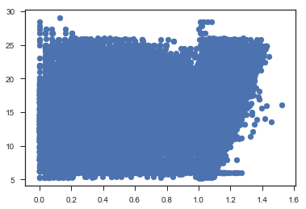

```python
%matplotlib inline
import matplotlib.pyplot as plt

plt.scatter(feat_raw.balance1,feat_raw.int_rate)
plt.show()
```

```python
feat_raw.query('balance1>5 & num_pymnts==0')
```

|  | id | loan_amnt | term | int_rate | installment | sub_grade | emp_title | emp_length | home_ownership | annual_inc | loan_status | purpose | addr_state | dti | delinq_2yrs | earliest_cr_line | inq_last_6mths | mths_since_last_delinq | mths_since_last_record | open_acc | pub_rec | revol_bal | revol_util | total_acc | total_pymnt | total_rec_prncp | total_rec_int | total_rec_late_fee | recoveries | … |
| --- | --- | --- | --- | --- | --- | --- | --- | --- | --- | --- | --- | --- | --- | --- | --- | --- | --- | --- | --- | --- | --- | --- | --- | --- | --- | --- | --- | --- | --- | --- |

## Fixing the metric

As most in this data have at least a year's worth of data, I will approach this with two things: first by removing 'current' loans with less than normal number of payments, and secondly, by attenuating large lump sums payments that do not fully pay the loan.

### First, filter current loans with less than expected number of payments

Explicitly, we want to exclude loans that show less than 11 payments, but are marked "current", NOT loans with less than normal payments that are late, defaulted, or charged off. A non-negligible number of loans default with no payments at all. This gets rid of loans that people pay large lump sums and then stop paying for a while. It does NOT get rid of loans with large lump sums and then all the regular payments.

```python
feat_inform=feat_raw.query('(num_pymnts >11 & current==True) | current==False')
```

```python
feat_inform[['balance1','balance2','pymnts_left','loan_status','total_rec_prncp','total_rec_int','total_rec_late_fee']]
```

|  | balance1 | balance2 | pymnts_left | loan_status | total_rec_prncp | total_rec_int | total_rec_late_fee |
| --- | --- | --- | --- | --- | --- | --- | --- |
| 0 | 1.172214 | 1.172214 | -1.0 | Fully Paid | 5000.00 | 861.07 | 0.00 |
| 1 | 1.251522 | 1.251522 | 6.0 | Fully Paid | 2400.00 | 603.65 | 0.00 |
| 2 | 1.222630 | 1.222630 | -1.0 | Fully Paid | 10000.00 | 2209.33 | 16.97 |
| 3 | 1.126276 | 1.126276 | -1.0 | Fully Paid | 5000.00 | 631.38 | 0.00 |
| 4 | 1.312715 | 1.312715 | -1.0 | Fully Paid | 3000.00 | 938.14 | 0.00 |
| 5 | 1.161923 | 1.161923 | 15.0 | Fully Paid | 12000.00 | 1943.08 | 0.00 |
| 6 | 0.252300 | 0.252300 | 29.0 | Charged Off | 1256.14 | 570.26 | 0.00 |
| 7 | 1.159661 | 1.159661 | -1.0 | Fully Paid | 3000.00 | 478.98 | 0.00 |
| 8 | 0.747199 | 0.747199 | 14.0 | Charged Off | 5433.47 | 1393.42 | 0.00 |
| 9 | 1.270171 | 1.270171 | -1.0 | Fully Paid | 1000.00 | 270.17 | 0.00 |
| 10 | 1.251926 | 1.251926 | -1.0 | Fully Paid | 10000.00 | 2519.26 | 0.00 |
| 11 | 1.051394 | 1.051394 | 19.0 | Fully Paid | 3600.00 | 185.02 | 0.00 |
| 12 | 1.194083 | 1.194083 | -2.0 | Fully Paid | 6000.00 | 1149.50 | 15.00 |
| 13 | 1.028257 | 1.028257 | 29.0 | Fully Paid | 9200.00 | 259.96 | 0.00 |
| 14 | 0.667876 | 0.667876 | 15.0 | Charged Off | 10694.96 | 3330.44 | 0.00 |
| 15 | 1.190256 | 1.190256 | -1.0 | Fully Paid | 10000.00 | 1902.56 | 0.00 |
| 16 | 1.153631 | 1.153631 | 14.0 | Fully Paid | 10000.00 | 1536.31 | 0.00 |
| 17 | 0.341690 | 0.341690 | 26.0 | Charged Off | 1305.58 | 475.25 | 0.00 |
| 18 | 1.054899 | 1.054899 | 27.0 | Fully Paid | 15000.00 | 823.48 | 0.00 |
| 19 | 0.000000 | 0.000000 | 0.0 | Charged Off | 0.00 | 0.00 | 0.00 |
| 20 | 1.121198 | 1.121198 | 20.0 | Fully Paid | 4000.00 | 484.79 | 0.00 |
| 21 | 1.190848 | 1.190848 | 0.0 | Fully Paid | 8500.00 | 1622.21 | 0.00 |
| 22 | 1.119667 | 1.119667 | -1.0 | Fully Paid | 4375.00 | 523.54 | 0.00 |
| 23 | 1.096185 | 1.096185 | 16.0 | Fully Paid | 31825.00 | 3061.08 | 0.00 |
| 24 | 1.142918 | 1.142918 | -1.0 | Fully Paid | 5000.00 | 714.59 | 0.00 |
| 25 | 1.264134 | 1.264134 | -1.0 | Fully Paid | 7000.00 | 1848.94 | 0.00 |
| 26 | 1.172376 | 1.172376 | -1.0 | Fully Paid | 12400.00 | 2137.46 | 0.00 |
| 27 | 1.125667 | 1.125667 | 13.0 | Fully Paid | 10800.00 | 1357.20 | 0.00 |
| 28 | 1.110840 | 1.110840 | 11.0 | Fully Paid | 15000.00 | 1662.60 | 0.00 |
| 29 | 1.187547 | 1.187547 | 8.0 | Fully Paid | 6000.00 | 1125.28 | 0.00 |

[output cut: 51 more lines]

209087 rows × 7 columns

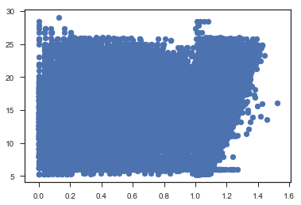

```python
%matplotlib inline
import matplotlib.pyplot as plt

plt.scatter(feat_inform.balance1,feat_inform.int_rate)
plt.show()
```

### Uninformative loans

This deals with abberant loans that aren't paid back on a monthly schedule.

### Large lump sum loans

```python
feat_inform['excess_pymnt']=(feat_inform.total_pymnt-feat_inform.total_rec_late_fee)/(feat_inform.installment*(feat_raw.term-feat_raw.pymnts_left))
```

```python
feat_inform.query('excess_pymnt>1.1 & current==True')
```

|  | id | loan_amnt | term | int_rate | installment | sub_grade | emp_title | emp_length | home_ownership | annual_inc | loan_status | purpose | addr_state | dti | delinq_2yrs | earliest_cr_line | inq_last_6mths | mths_since_last_delinq | mths_since_last_record | open_acc | pub_rec | revol_bal | revol_util | total_acc | total_pymnt | total_rec_prncp | total_rec_int | total_rec_late_fee | recoveries | … |
| --- | --- | --- | --- | --- | --- | --- | --- | --- | --- | --- | --- | --- | --- | --- | --- | --- | --- | --- | --- | --- | --- | --- | --- | --- | --- | --- | --- | --- | --- | --- |

### excess payment filter

```python
feat_inform=feat_inform.query('(excess_pymnt<1.1 & current==True) | current==False')
```

```python
feat_inform
```

|  | id | loan_amnt | term | int_rate | installment | sub_grade | emp_title | emp_length | home_ownership | annual_inc | loan_status | purpose | addr_state | dti | delinq_2yrs | earliest_cr_line | inq_last_6mths | mths_since_last_delinq | mths_since_last_record | open_acc | pub_rec | revol_bal | revol_util | total_acc | total_pymnt | total_rec_prncp | total_rec_int | total_rec_late_fee | recoveries | … |
| --- | --- | --- | --- | --- | --- | --- | --- | --- | --- | --- | --- | --- | --- | --- | --- | --- | --- | --- | --- | --- | --- | --- | --- | --- | --- | --- | --- | --- | --- | --- |
| 0 | 1077501 | 5000.0 | 36 | 10.65 | 162.87 | B2 | None | 10.0 | RENT | 24000.00 | Fully Paid | credit_card | AZ | 27.65 | 0.0 | 1985-01-01 | 1.0 | NaN | NaN | 3.0 | 0.0 | 13648.0 | 83.70 | 9.0 | 5861.071414 | 5000.00 | 861.07 | 0.00 | 0.00 | … |
| 1 | 1077175 | 2400.0 | 36 | 15.96 | 84.33 | C5 | None | 10.0 | RENT | 12252.00 | Fully Paid | small_business | IL | 8.72 | 0.0 | 2001-11-01 | 2.0 | NaN | NaN | 2.0 | 0.0 | 2956.0 | 98.50 | 10.0 | 3003.653644 | 2400.00 | 603.65 | 0.00 | 0.00 | … |
| 2 | 1076863 | 10000.0 | 36 | 13.49 | 339.31 | C1 | AIR RESOURCES BOARD | 10.0 | RENT | 49200.00 | Fully Paid | other | CA | 20.00 | 0.0 | 1996-02-01 | 1.0 | 35.0 | NaN | 10.0 | 0.0 | 5598.0 | 21.00 | 37.0 | 12226.302212 | 10000.00 | 2209.33 | 16.97 | 0.00 | … |
| 3 | 1075269 | 5000.0 | 36 | 7.90 | 156.46 | A4 | Veolia Transportaton | 3.0 | RENT | 36000.00 | Fully Paid | wedding | AZ | 11.20 | 0.0 | 2004-11-01 | 3.0 | NaN | NaN | 9.0 | 0.0 | 7963.0 | 28.30 | 12.0 | 5631.377753 | 5000.00 | 631.38 | 0.00 | 0.00 | … |
| 4 | 1072053 | 3000.0 | 36 | 18.64 | 109.43 | E1 | MKC Accounting | 9.0 | RENT | 48000.00 | Fully Paid | car | CA | 5.35 | 0.0 | 2007-01-01 | 2.0 | NaN | NaN | 4.0 | 0.0 | 8221.0 | 87.50 | 4.0 | 3938.144334 | 3000.00 | 938.14 | 0.00 | 0.00 | … |
| 5 | 1069908 | 12000.0 | 36 | 12.69 | 402.54 | B5 | UCLA | 10.0 | OWN | 75000.00 | Fully Paid | debt_consolidation | CA | 10.78 | 0.0 | 1989-10-01 | 0.0 | NaN | NaN | 12.0 | 0.0 | 23336.0 | 67.10 | 34.0 | 13943.080000 | 12000.00 | 1943.08 | 0.00 | 0.00 | … |
| 6 | 1064687 | 9000.0 | 36 | 13.49 | 305.38 | C1 | Va. Dept of Conservation/Recreation | 0.5 | RENT | 30000.00 | Charged Off | debt_consolidation | VA | 10.08 | 0.0 | 2004-04-01 | 1.0 | NaN | NaN | 4.0 | 0.0 | 10452.0 | 91.70 | 9.0 | 2270.700000 | 1256.14 | 570.26 | 0.00 | 444.30 | … |
| 7 | 1069866 | 3000.0 | 36 | 9.91 | 96.68 | B1 | Target | 3.0 | RENT | 15000.00 | Fully Paid | credit_card | IL | 12.56 | 0.0 | 2003-07-01 | 2.0 | NaN | NaN | 11.0 | 0.0 | 7323.0 | 43.10 | 11.0 | 3478.981915 | 3000.00 | 478.98 | 0.00 | 0.00 | … |
| 8 | 1069057 | 10000.0 | 36 | 10.65 | 325.74 | B2 | SFMTA | 3.0 | RENT | 100000.00 | Charged Off | other | CA | 7.06 | 0.0 | 1991-05-01 | 2.0 | NaN | NaN | 14.0 | 0.0 | 11997.0 | 55.50 | 29.0 | 7471.990000 | 5433.47 | 1393.42 | 0.00 | 645.10 | … |
| 9 | 1069759 | 1000.0 | 36 | 16.29 | 35.31 | D1 | Internal revenue Service | 0.5 | RENT | 28000.00 | Fully Paid | debt_consolidation | MO | 20.31 | 0.0 | 2007-09-01 | 1.0 | NaN | NaN | 11.0 | 0.0 | 6524.0 | 81.50 | 23.0 | 1270.171106 | 1000.00 | 270.17 | 0.00 | 0.00 | … |
| 10 | 1065775 | 10000.0 | 36 | 15.27 | 347.98 | C4 | Chin's Restaurant | 4.0 | RENT | 42000.00 | Fully Paid | home_improvement | CA | 18.60 | 0.0 | 1998-10-01 | 2.0 | 61.0 | NaN | 14.0 | 0.0 | 24043.0 | 70.20 | 28.0 | 12519.260450 | 10000.00 | 2519.26 | 0.00 | 0.00 | … |
| 11 | 1069971 | 3600.0 | 36 | 6.03 | 109.57 | A1 | Duracell | 10.0 | MORTGAGE | 110000.00 | Fully Paid | major_purchase | CT | 10.52 | 0.0 | 1993-08-01 | 0.0 | NaN | NaN | 20.0 | 0.0 | 22836.0 | 16.00 | 42.0 | 3785.020000 | 3600.00 | 185.02 | 0.00 | 0.00 | … |
| 12 | 1062474 | 6000.0 | 36 | 11.71 | 198.46 | B3 | Connection Inspection | 1.0 | MORTGAGE | 84000.00 | Fully Paid | medical | UT | 18.44 | 2.0 | 2003-10-01 | 0.0 | 8.0 | NaN | 4.0 | 0.0 | 0.0 | 37.73 | 14.0 | 7164.499852 | 6000.00 | 1149.50 | 15.00 | 0.00 | … |
| 13 | 1069742 | 9200.0 | 36 | 6.03 | 280.01 | A1 | Network Interpreting Service | 6.0 | RENT | 77385.19 | Fully Paid | debt_consolidation | CA | 9.86 | 0.0 | 2001-01-01 | 0.0 | NaN | NaN | 8.0 | 0.0 | 7314.0 | 23.10 | 28.0 | 9459.960000 | 9200.00 | 259.96 | 0.00 | 0.00 | … |
| 14 | 1039153 | 21000.0 | 36 | 12.42 | 701.73 | B4 | Osram Sylvania | 10.0 | RENT | 105000.00 | Charged Off | debt_consolidation | FL | 13.22 | 0.0 | 1983-02-01 | 0.0 | NaN | NaN | 7.0 | 0.0 | 32135.0 | 90.30 | 38.0 | 14025.400000 | 10694.96 | 3330.44 | 0.00 | 0.00 | … |
| 15 | 1069710 | 10000.0 | 36 | 11.71 | 330.76 | B3 | Value Air | 10.0 | OWN | 50000.00 | Fully Paid | credit_card | TX | 11.18 | 0.0 | 1985-07-01 | 0.0 | NaN | NaN | 8.0 | 0.0 | 10056.0 | 82.40 | 21.0 | 11902.561575 | 10000.00 | 1902.56 | 0.00 | 0.00 | … |
| 16 | 1069700 | 10000.0 | 36 | 11.71 | 330.76 | B3 | Wells Fargo Bank | 5.0 | RENT | 50000.00 | Fully Paid | debt_consolidation | CA | 16.01 | 0.0 | 2003-04-01 | 0.0 | NaN | NaN | 6.0 | 0.0 | 17800.0 | 91.80 | 17.0 | 11536.310000 | 10000.00 | 1536.31 | 0.00 | 0.00 | … |
| 17 | 1069559 | 6000.0 | 36 | 11.71 | 198.46 | B3 | bmg-educational | 1.0 | RENT | 76000.00 | Charged Off | major_purchase | CA | 2.40 | 0.0 | 2001-06-01 | 1.0 | NaN | NaN | 7.0 | 0.0 | 5963.0 | 29.70 | 7.0 | 2050.140000 | 1305.58 | 475.25 | 0.00 | 269.31 | … |
| 18 | 1069697 | 15000.0 | 36 | 9.91 | 483.38 | B1 | Winfield Pathology Consultants | 2.0 | MORTGAGE | 92000.00 | Fully Paid | credit_card | IL | 29.44 | 0.0 | 2002-02-01 | 0.0 | NaN | NaN | 8.0 | 0.0 | 13707.0 | 93.90 | 31.0 | 15823.480000 | 15000.00 | 823.48 | 0.00 | 0.00 | … |
| 19 | 1069800 | 15000.0 | 36 | 14.27 | 514.64 | C2 | nyc transit | 9.0 | RENT | 60000.00 | Charged Off | debt_consolidation | NY | 15.22 | 0.0 | 2003-10-01 | 1.0 | NaN | NaN | 7.0 | 0.0 | 5872.0 | 57.60 | 11.0 | 0.000000 | 0.00 | 0.00 | 0.00 | 0.00 | … |
| 20 | 1069799 | 4000.0 | 36 | 11.71 | 132.31 | B3 | Shands Hospital at the University of Fl | 10.0 | MORTGAGE | 106000.00 | Fully Paid | debt_consolidation | FL | 5.63 | 1.0 | 1984-08-01 | 0.0 | 18.0 | NaN | 12.0 | 0.0 | 6110.0 | 37.70 | 44.0 | 4484.790000 | 4000.00 | 484.79 | 0.00 | 0.00 | … |
| 21 | 1047704 | 8500.0 | 36 | 11.71 | 281.15 | B3 | Oakridge homes | 0.5 | RENT | 25000.00 | Fully Paid | credit_card | MN | 12.19 | 0.0 | 2006-11-01 | 0.0 | NaN | NaN | 8.0 | 0.0 | 6441.0 | 59.10 | 12.0 | 10122.208614 | 8500.00 | 1622.21 | 0.00 | 0.00 | … |
| 22 | 1032111 | 4375.0 | 36 | 7.51 | 136.11 | A3 | None | 7.0 | MORTGAGE | 17108.00 | Fully Paid | debt_consolidation | NY | 20.34 | 0.0 | 1987-12-01 | 0.0 | NaN | NaN | 6.0 | 0.0 | 11210.0 | 86.90 | 12.0 | 4898.543558 | 4375.00 | 523.54 | 0.00 | 0.00 | … |
| 23 | 1069539 | 31825.0 | 36 | 7.90 | 995.82 | A4 | Audubon Mutual Housing Corporation | 5.0 | MORTGAGE | 75000.00 | Fully Paid | debt_consolidation | NJ | 14.03 | 0.0 | 1981-11-01 | 0.0 | NaN | NaN | 12.0 | 0.0 | 23151.0 | 27.40 | 26.0 | 34886.080000 | 31825.00 | 3061.08 | 0.00 | 0.00 | … |
| 24 | 1069591 | 5000.0 | 36 | 8.90 | 158.77 | A5 | Good Samaritan Society | 2.0 | RENT | 24044.00 | Fully Paid | debt_consolidation | OR | 11.93 | 0.0 | 2005-04-01 | 0.0 | 45.0 | NaN | 8.0 | 0.0 | 2224.0 | 29.30 | 16.0 | 5714.592129 | 5000.00 | 714.59 | 0.00 | 0.00 | … |
| 25 | 1069530 | 7000.0 | 36 | 15.96 | 245.97 | C5 | GREG BARRETT DRYWALL | 7.0 | RENT | 34000.00 | Fully Paid | credit_card | CA | 6.35 | 0.0 | 2007-10-01 | 1.0 | NaN | NaN | 6.0 | 0.0 | 6113.0 | 60.50 | 6.0 | 8848.940430 | 7000.00 | 1848.94 | 0.00 | 0.00 | … |
| 26 | 1069522 | 12400.0 | 36 | 10.65 | 403.91 | B2 | Sharp Lawn Inc. | 10.0 | RENT | 41000.00 | Fully Paid | credit_card | KY | 11.80 | 0.0 | 2005-07-01 | 2.0 | NaN | NaN | 9.0 | 0.0 | 11095.0 | 57.20 | 12.0 | 14537.459527 | 12400.00 | 2137.46 | 0.00 | 0.00 | … |
| 27 | 1069361 | 10800.0 | 36 | 9.91 | 348.03 | B1 | Department of Justice | 2.0 | RENT | 55596.00 | Fully Paid | moving | CA | 5.50 | 0.0 | 2000-12-01 | 0.0 | NaN | NaN | 7.0 | 0.0 | 2535.0 | 13.30 | 18.0 | 12157.200000 | 10800.00 | 1357.20 | 0.00 | 0.00 | … |
| 28 | 1069357 | 15000.0 | 36 | 7.90 | 469.36 | A4 | Gateway Hospice | 1.0 | RENT | 45000.00 | Fully Paid | debt_consolidation | OH | 8.48 | 0.0 | 2004-11-01 | 0.0 | NaN | NaN | 7.0 | 0.0 | 6704.0 | 50.40 | 27.0 | 16662.600000 | 15000.00 | 1662.60 | 0.00 | 0.00 | … |
| 29 | 1069356 | 6000.0 | 36 | 12.42 | 200.50 | B4 | Cox Communications | 1.0 | RENT | 36852.00 | Fully Paid | debt_consolidation | AZ | 10.62 | 0.0 | 2007-04-01 | 1.0 | NaN | NaN | 7.0 | 0.0 | 7310.0 | 66.50 | 12.0 | 7125.283165 | 6000.00 | 1125.28 | 0.00 | 0.00 | … |

[output cut: 51 more lines]

209087 rows × 43 columns

```python
feat_inform=feat_inform.query('purpose=="credit_card" | purpose=="debt_consolidation"')
feat_inform=feat_inform.query('home_ownership!="ANY" &home_ownership!="OTHER"& home_ownership!="NONE"')
```

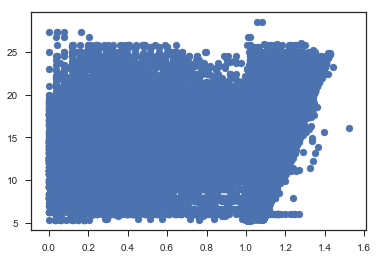

```python
%matplotlib inline
import matplotlib.pyplot as plt

plt.scatter(feat_inform.balance1,feat_inform.int_rate)
plt.show()
```

```python
feat_raw.query('int_rate> 28')
```

|  | id | loan_amnt | term | int_rate | installment | sub_grade | emp_title | emp_length | home_ownership | annual_inc | loan_status | purpose | addr_state | dti | delinq_2yrs | earliest_cr_line | inq_last_6mths | mths_since_last_delinq | mths_since_last_record | open_acc | pub_rec | revol_bal | revol_util | total_acc | total_pymnt | total_rec_prncp | total_rec_int | total_rec_late_fee | recoveries | … |
| --- | --- | --- | --- | --- | --- | --- | --- | --- | --- | --- | --- | --- | --- | --- | --- | --- | --- | --- | --- | --- | --- | --- | --- | --- | --- | --- | --- | --- | --- | --- |
| 361979 | 66320245 | 9500.0 | 36 | 28.49 | 395.48 | G4 | Van Driver | 10.0 | RENT | 29743.0 | In Grace Period | medical | CA | 24.46 | 0.0 | 1995-12-01 | 1.0 | NaN | NaN | 8.0 | 0.0 | 6909.0 | 33.9 | 10.0 | 0.00 | 0.00 | 0.00 | 0.00 | 0.0 | … |
| 447942 | 58563231 | 11975.0 | 36 | 28.99 | 501.76 | G5 | credit and collection specialist | 8.0 | MORTGAGE | 60000.0 | Late (31-120 days) | house | NJ | 24.43 | 2.0 | 1994-02-01 | 4.0 | 15.0 | NaN | 21.0 | 0.0 | 4037.0 | 33.1 | 60.0 | 1553.49 | 652.91 | 900.58 | 0.00 | 0.0 | … |
| 452438 | 57991149 | 6375.0 | 36 | 28.49 | 265.39 | G4 | factory worker | 8.0 | OWN | 24000.0 | Fully Paid | debt_consolidation | NJ | 19.40 | 0.0 | 2007-07-01 | 0.0 | NaN | NaN | 6.0 | 0.0 | 13722.0 | 65.3 | 6.0 | 6727.76 | 6375.00 | 352.76 | 0.00 | 0.0 | … |
| 453923 | 57950353 | 7200.0 | 36 | 28.49 | 299.73 | G4 | front end manager | 3.0 | RENT | 24000.0 | Fully Paid | house | WA | 15.95 | 0.0 | 2009-12-01 | 1.0 | NaN | NaN | 12.0 | 0.0 | 897.0 | 8.5 | 15.0 | 7433.93 | 7200.00 | 233.93 | 0.00 | 0.0 | … |
| 472451 | 56059424 | 13800.0 | 36 | 28.49 | 574.48 | G4 | mechanic | 2.0 | RENT | 38400.0 | Late (31-120 days) | debt_consolidation | CA | 29.72 | 0.0 | 1989-02-01 | 1.0 | NaN | NaN | 6.0 | 0.0 | 15887.0 | 66.8 | 12.0 | 14895.66 | 13800.00 | 1066.94 | 28.72 | 0.0 | … |
| 490896 | 54393585 | 3875.0 | 36 | 28.49 | 161.32 | G4 | Production Assistant | 9.0 | OWN | 20000.0 | Fully Paid | house | CA | 20.05 | 1.0 | 1996-12-01 | 2.0 | 6.0 | NaN | 9.0 | 0.0 | 439.0 | 25.8 | 11.0 | 3924.07 | 3875.00 | 49.07 | 0.00 | 0.0 | … |

## Setting up the features

Worth noting, a lot of the features in the dataset related to payments are clearly not available at the beginning of the loan, and therefore are not predictive when choosing new loans to fund. The metric also is highly correlated to the given rating and interest rate set by LC. Additionally, a lot of the other data is highly correlated.

```python
feat_inform.columns.values
```

```
array(['id', 'loan_amnt', 'term', 'int_rate', 'installment', 'sub_grade',
       'emp_title', 'emp_length', 'home_ownership', 'annual_inc',
       'loan_status', 'purpose', 'addr_state', 'dti', 'delinq_2yrs',
       'earliest_cr_line', 'inq_last_6mths', 'mths_since_last_delinq',
       'mths_since_last_record', 'open_acc', 'pub_rec', 'revol_bal',
       'revol_util', 'total_acc', 'total_pymnt', 'total_rec_prncp',
       'total_rec_int', 'total_rec_late_fee', 'recoveries',
       'collection_recovery_fee', 'last_pymnt_d', 'last_pymnt_amnt',
       'next_pymnt_d', 'collections_12_mths_ex_med',
       'mths_since_last_major_derog', 'issue_d', 'num_pymnts',
       'pymnts_left', 'current', 'balance1', 'balance2', 'class_label',
       'excess_pymnt'], dtype=object)
```

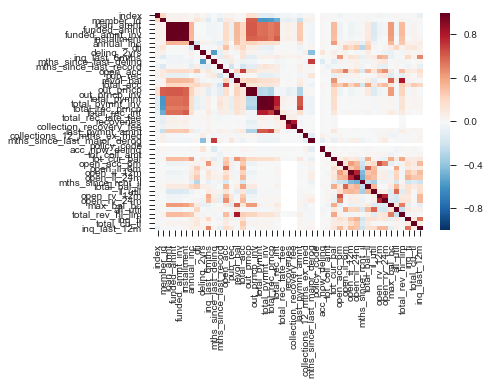

```python
import seaborn as sns
corr=data.corr()
sns.heatmap(corr)
#g=sns.pairplot(data)
```

Looking at the raw data, some of the correlations are obvious: loan amount, funding amount, and installment are closely tied (or identical). the payment information is highly correlated with itself as well as the funding amounts. delinquencies and records are correlated, balance amounts are correlated.

Looking at the feature data, there are still correlations - mostly due to payment info, and info that will not be attached to new loans. I will create my final feature set below based on the corr map and data dictionary.

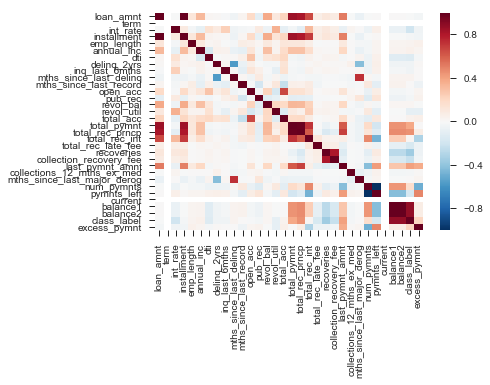

```python
corr=feat_inform.corr()
sns.heatmap(corr)
```

Interestingly you can get an idea of what numeric (I find them to be continuous as well) values are correlated with the given interest rate: mainly inquiries, delinquincies, dti, and public records; as well as annual income and total accounts with a negative corr. What is tricky are the 'months since last *__*' features, as they include a bunch of NaNs, indicating no issues. NaNs can be tricky with ML algos, and beyond setting NaNs to a large number (like 1200 months, or 100 years), it would be hard to work around them. To be safe and simple, I will exclude them from my final features, but if I am unsatisfied I may find a way to include them.

```python
keepfeat=['sub_grade','loan_amnt', 'emp_title', 'emp_length', 'home_ownership',
       'annual_inc','purpose',
       'addr_state', 'dti', 'delinq_2yrs', 'earliest_cr_line',
       'inq_last_6mths','open_acc', 'pub_rec', 'revol_bal',
       'revol_util', 'total_acc','collections_12_mths_ex_med']
features=feat_inform[keepfeat]
```

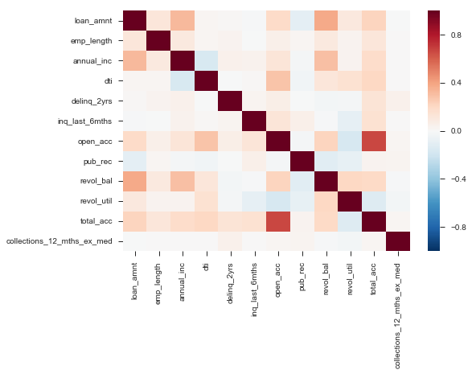

```python
corr=features.corr()
g=sns.heatmap(corr)
```

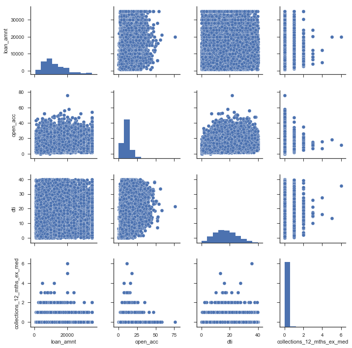

```python
sns.set(style="ticks", color_codes=True)
g=sns.pairplot(features,vars=['loan_amnt' ,'open_acc', 'dti','collections_12_mths_ex_med'])
```

```python
features.isnull().sum()
```

```
sub_grade                        0
loan_amnt                        0
emp_title                     9139
emp_length                       0
home_ownership                   0
annual_inc                       0
purpose                          0
addr_state                       0
dti                              0
delinq_2yrs                      0
earliest_cr_line                 0
inq_last_6mths                   0
open_acc                         0
pub_rec                          0
revol_bal                        0
revol_util                       0
total_acc                        0
collections_12_mths_ex_med       0
dtype: int64
```

One last thing, check those nulls in emp title, they should be "None". This is fine, as it can be its own category when they are one hot encoded!

```python
features.query('emp_title!=emp_title')
```

|  | sub_grade | loan_amnt | emp_title | emp_length | home_ownership | annual_inc | purpose | addr_state | dti | delinq_2yrs | earliest_cr_line | inq_last_6mths | open_acc | pub_rec | revol_bal | revol_util | total_acc | collections_12_mths_ex_med |
| --- | --- | --- | --- | --- | --- | --- | --- | --- | --- | --- | --- | --- | --- | --- | --- | --- | --- | --- |
| 0 | B2 | 5000.0 | None | 10.0 | RENT | 24000.0 | credit_card | AZ | 27.65 | 0.0 | 1985-01-01 | 1.0 | 3.0 | 0.0 | 13648.0 | 83.7 | 9.0 | 0.0 |
| 22 | A3 | 4375.0 | None | 7.0 | MORTGAGE | 17108.0 | debt_consolidation | NY | 20.34 | 0.0 | 1987-12-01 | 0.0 | 6.0 | 0.0 | 11210.0 | 86.9 | 12.0 | 0.0 |
| 125 | A3 | 2500.0 | None | 0.0 | OWN | 12000.0 | debt_consolidation | CA | 16.30 | 0.0 | 1994-08-01 | 2.0 | 13.0 | 0.0 | 4853.0 | 42.2 | 20.0 | 0.0 |
| 140 | B2 | 9000.0 | None | 9.0 | MORTGAGE | 74000.0 | credit_card | SD | 8.89 | 0.0 | 1998-09-01 | 0.0 | 7.0 | 0.0 | 7388.0 | 71.7 | 10.0 | 0.0 |
| 150 | C1 | 20000.0 | None | 6.0 | RENT | 75000.0 | debt_consolidation | CA | 22.38 | 0.0 | 1998-11-01 | 1.0 | 7.0 | 0.0 | 19548.0 | 90.8 | 17.0 | 0.0 |
| 185 | C1 | 6000.0 | None | 5.0 | MORTGAGE | 50000.0 | debt_consolidation | NM | 15.58 | 0.0 | 2003-05-01 | 1.0 | 8.0 | 0.0 | 7361.0 | 83.6 | 14.0 | 0.0 |
| 205 | B3 | 7000.0 | None | 2.0 | RENT | 75000.0 | debt_consolidation | CA | 15.57 | 0.0 | 2001-01-01 | 0.0 | 7.0 | 0.0 | 22196.0 | 94.1 | 17.0 | 0.0 |
| 222 | B1 | 10400.0 | None | 6.0 | RENT | 40000.0 | debt_consolidation | FL | 11.67 | 0.0 | 1999-10-01 | 2.0 | 7.0 | 0.0 | 11624.0 | 80.6 | 19.0 | 0.0 |
| 330 | A5 | 7000.0 | None | 1.0 | RENT | 46000.0 | credit_card | VA | 7.90 | 0.0 | 2002-08-01 | 1.0 | 7.0 | 0.0 | 8717.0 | 76.5 | 18.0 | 0.0 |
| 332 | A3 | 8250.0 | None | 0.0 | MORTGAGE | 31500.0 | debt_consolidation | MD | 17.87 | 0.0 | 1981-12-01 | 4.0 | 17.0 | 0.0 | 7521.0 | 10.4 | 37.0 | 0.0 |
| 360 | A5 | 3600.0 | None | 10.0 | RENT | 55000.0 | debt_consolidation | NY | 5.48 | 0.0 | 2002-06-01 | 0.0 | 8.0 | 0.0 | 9550.0 | 65.9 | 18.0 | 0.0 |
| 410 | B2 | 6200.0 | None | 10.0 | MORTGAGE | 24000.0 | credit_card | AK | 19.95 | 0.0 | 2001-10-01 | 1.0 | 10.0 | 0.0 | 18210.0 | 55.2 | 11.0 | 0.0 |
| 424 | D4 | 8575.0 | None | 0.0 | MORTGAGE | 32000.0 | debt_consolidation | FL | 22.54 | 0.0 | 2004-09-01 | 1.0 | 4.0 | 0.0 | 20142.0 | 89.9 | 5.0 | 0.0 |
| 431 | A5 | 8000.0 | None | 3.0 | MORTGAGE | 120000.0 | credit_card | CA | 10.52 | 0.0 | 2000-10-01 | 0.0 | 10.0 | 0.0 | 13268.0 | 60.6 | 15.0 | 0.0 |
| 493 | B4 | 10700.0 | None | 4.0 | RENT | 68000.0 | debt_consolidation | AZ | 16.41 | 0.0 | 2005-09-01 | 1.0 | 7.0 | 0.0 | 5192.0 | 66.6 | 12.0 | 0.0 |
| 557 | B4 | 14125.0 | None | 0.0 | MORTGAGE | 45696.0 | debt_consolidation | NC | 21.93 | 0.0 | 2000-08-01 | 0.0 | 10.0 | 0.0 | 15831.0 | 91.5 | 26.0 | 0.0 |
| 571 | C3 | 10500.0 | None | 1.0 | MORTGAGE | 42000.0 | debt_consolidation | GA | 10.77 | 0.0 | 2002-03-01 | 2.0 | 7.0 | 0.0 | 16705.0 | 52.2 | 23.0 | 0.0 |
| 620 | B5 | 12000.0 | None | 2.0 | RENT | 60000.0 | credit_card | CT | 18.38 | 0.0 | 2005-03-01 | 0.0 | 6.0 | 0.0 | 16464.0 | 89.5 | 6.0 | 0.0 |
| 629 | B4 | 17050.0 | None | 10.0 | MORTGAGE | 53000.0 | debt_consolidation | GA | 23.64 | 0.0 | 1995-09-01 | 1.0 | 8.0 | 0.0 | 17414.0 | 59.4 | 28.0 | 0.0 |
| 637 | B2 | 30000.0 | None | 7.0 | MORTGAGE | 175000.0 | debt_consolidation | TX | 17.15 | 0.0 | 1993-10-01 | 1.0 | 12.0 | 0.0 | 26103.0 | 56.9 | 47.0 | 0.0 |
| 716 | B4 | 4000.0 | None | 7.0 | RENT | 100000.0 | credit_card | NY | 9.60 | 0.0 | 2002-06-01 | 3.0 | 15.0 | 0.0 | 12710.0 | 54.9 | 39.0 | 0.0 |
| 717 | B4 | 15000.0 | None | 0.0 | RENT | 60000.0 | debt_consolidation | WA | 14.18 | 0.0 | 1993-08-01 | 0.0 | 8.0 | 0.0 | 15451.0 | 72.5 | 19.0 | 0.0 |
| 779 | A1 | 12000.0 | None | 0.0 | OWN | 40000.0 | credit_card | GA | 18.75 | 0.0 | 1981-06-01 | 0.0 | 10.0 | 0.0 | 20899.0 | 51.1 | 25.0 | 0.0 |
| 780 | D3 | 15000.0 | None | 0.0 | OWN | 57000.0 | debt_consolidation | CA | 12.08 | 0.0 | 2006-09-01 | 1.0 | 13.0 | 0.0 | 16549.0 | 89.0 | 13.0 | 0.0 |
| 791 | A4 | 18000.0 | None | 10.0 | MORTGAGE | 60000.0 | debt_consolidation | SD | 21.22 | 0.0 | 1996-09-01 | 0.0 | 12.0 | 0.0 | 27390.0 | 71.5 | 28.0 | 0.0 |
| 794 | C4 | 11100.0 | None | 6.0 | RENT | 45000.0 | debt_consolidation | NY | 4.64 | 0.0 | 1996-12-01 | 1.0 | 3.0 | 0.0 | 9866.0 | 95.8 | 9.0 | 0.0 |
| 799 | C5 | 8500.0 | None | 0.0 | RENT | 27050.0 | credit_card | GA | 10.25 | 0.0 | 2005-10-01 | 3.0 | 7.0 | 0.0 | 5956.0 | 62.7 | 10.0 | 0.0 |
| 806 | A5 | 6000.0 | None | 5.0 | RENT | 24000.0 | credit_card | FL | 11.55 | 0.0 | 2000-02-01 | 0.0 | 4.0 | 0.0 | 7186.0 | 88.7 | 9.0 | 0.0 |
| 818 | C4 | 4000.0 | None | 0.0 | OWN | 25000.0 | debt_consolidation | TX | 12.62 | 0.0 | 2003-01-01 | 1.0 | 5.0 | 0.0 | 5550.0 | 91.0 | 9.0 | 0.0 |
| 822 | B3 | 3000.0 | None | 3.0 | RENT | 55000.0 | credit_card | IL | 9.75 | 0.0 | 2001-05-01 | 0.0 | 12.0 | 0.0 | 11679.0 | 92.7 | 19.0 | 0.0 |

[output cut: 51 more lines]

9139 rows × 18 columns

### Keep the label as well!

```python
labels=pd.DataFrame
classlabels=pd.DataFrame
labels=feat_inform['balance1']
classlabels=feat_inform['class_label']
```

```python
labels
```

```
0         1.172214
5         1.161923
6         0.252300
7         1.159661
9         1.270171
13        1.028257
14        0.667876
15        1.190256
16        1.153631
18        1.054899
19        0.000000
20        1.121198
21        1.190848
22        1.119667
23        1.096185
```

[output cut: 67 more lines]

## Export the data

```python
import joblib
joblib.dump(features,'clean_LCfeatures.p')
joblib.dump(labels,'clean_LClabels.p')
joblib.dump(classlabels,'clean_LCclassifierlabel.p')
```

```
['clean_LCclassifierlabel.p']
```

```python
feat_inform.query('class_label==1').describe()
```

|  | loan_amnt | term | int_rate | installment | emp_length | annual_inc | dti | delinq_2yrs | inq_last_6mths | mths_since_last_delinq | mths_since_last_record | open_acc | pub_rec | revol_bal | revol_util | total_acc | total_pymnt | total_rec_prncp | total_rec_int | total_rec_late_fee | recoveries | collection_recovery_fee | last_pymnt_amnt | collections_12_mths_ex_med | mths_since_last_major_derog | num_pymnts | pymnts_left | balance1 | balance2 | … |
| --- | --- | --- | --- | --- | --- | --- | --- | --- | --- | --- | --- | --- | --- | --- | --- | --- | --- | --- | --- | --- | --- | --- | --- | --- | --- | --- | --- | --- | --- | --- |
| count | 130086.000000 | 130086.0 | 130086.000000 | 130086.000000 | 130086.000000 | 1.300860e+05 | 130086.000000 | 130086.000000 | 130086.000000 | 57608.000000 | 16891.000000 | 130086.000000 | 130086.000000 | 1.300860e+05 | 130086.000000 | 130086.000000 | 130086.000000 | 130086.000000 | 130086.000000 | 130086.000000 | 130086.0 | 130086.0 | 130086.000000 | 130086.000000 | 25275.000000 | 130086.000000 | 130086.000000 | 130086.000000 | 130086.000000 | … |
| mean | 12549.847409 | 36.0 | 12.362191 | 419.291340 | 5.595798 | 7.107115e+04 | 16.603720 | 0.241448 | 0.775441 | 35.667893 | 75.640223 | 11.032609 | 0.148533 | 1.513643e+04 | 55.265404 | 25.054064 | 14151.448831 | 12532.587633 | 1618.556307 | 0.304897 | 0.0 | 0.0 | 6526.780219 | 0.006503 | 43.687478 | 18.034677 | 17.965323 | 1.126780 | 1.126780 | … |
| std | 7225.967110 | 0.0 | 3.611199 | 244.601934 | 3.653889 | 5.625120e+04 | 7.486221 | 0.730637 | 1.011112 | 21.706118 | 29.169557 | 4.818621 | 0.441061 | 1.781933e+04 | 23.442999 | 11.597379 | 8268.084573 | 7227.083159 | 1461.600690 | 3.456548 | 0.0 | 0.0 | 6099.918680 | 0.089607 | 21.592163 | 11.175401 | 11.175401 | 0.079349 | 0.079349 | … |
| min | 700.000000 | 36.0 | 5.320000 | 22.510000 | 0.000000 | 4.800000e+03 | 0.000000 | 0.000000 | 0.000000 | 0.000000 | 0.000000 | 1.000000 | 0.000000 | 0.000000e+00 | 0.000000 | 2.000000 | 0.000000 | 0.000000 | 0.000000 | 0.000000 | 0.0 | 0.0 | 0.000000 | 0.000000 | 0.000000 | 0.000000 | -34.000000 | 0.000000 | 0.000000 | … |
| 25% | 7200.000000 | 36.0 | 9.670000 | 243.480000 | 2.000000 | 4.500000e+04 | 10.980000 | 0.000000 | 0.000000 | 17.000000 | 55.000000 | 8.000000 | 0.000000 | 6.384000e+03 | 38.200000 | 17.000000 | 8141.717500 | 7200.000000 | 628.970000 | 0.000000 | 0.0 | 0.0 | 1520.572500 | 0.000000 | 27.000000 | 9.000000 | 9.000000 | 1.071670 | 1.071670 | … |
| 50% | 10625.000000 | 36.0 | 12.350000 | 360.080000 | 5.000000 | 6.000200e+04 | 16.170000 | 0.000000 | 0.000000 | 33.000000 | 78.000000 | 10.000000 | 0.000000 | 1.110200e+04 | 56.200000 | 23.000000 | 12212.643513 | 10625.000000 | 1226.175000 | 0.000000 | 0.0 | 0.0 | 5199.690000 | 0.000000 | 43.000000 | 16.000000 | 20.000000 | 1.119886 | 1.119886 | … |
| 75% | 16000.000000 | 36.0 | 14.640000 | 539.395000 | 10.000000 | 8.500000e+04 | 21.810000 | 0.000000 | 1.000000 | 52.000000 | 101.000000 | 14.000000 | 0.000000 | 1.873600e+04 | 73.500000 | 32.000000 | 18244.035070 | 16000.000000 | 2150.647500 | 0.000000 | 0.0 | 0.0 | 9413.387500 | 0.000000 | 60.000000 | 27.000000 | 27.000000 | 1.178824 | 1.178824 | … |
| max | 35000.000000 | 36.0 | 28.490000 | 1409.990000 | 10.000000 | 7.141778e+06 | 39.990000 | 29.000000 | 8.000000 | 151.000000 | 121.000000 | 58.000000 | 15.000000 | 1.743266e+06 | 892.300000 | 118.000000 | 49978.687781 | 35000.020000 | 14978.690000 | 286.747566 | 0.0 | 0.0 | 36188.840000 | 6.000000 | 159.000000 | 70.000000 | 36.000000 | 1.522311 | 1.522311 | … |

```python
feat_inform.query('class_label==0').describe()
```

|  | loan_amnt | term | int_rate | installment | emp_length | annual_inc | dti | delinq_2yrs | inq_last_6mths | mths_since_last_delinq | mths_since_last_record | open_acc | pub_rec | revol_bal | revol_util | total_acc | total_pymnt | total_rec_prncp | total_rec_int | total_rec_late_fee | recoveries | collection_recovery_fee | last_pymnt_amnt | collections_12_mths_ex_med | mths_since_last_major_derog | num_pymnts | pymnts_left | balance1 | balance2 | … |
| --- | --- | --- | --- | --- | --- | --- | --- | --- | --- | --- | --- | --- | --- | --- | --- | --- | --- | --- | --- | --- | --- | --- | --- | --- | --- | --- | --- | --- | --- | --- |
| count | 32874.000000 | 32874.0 | 32874.000000 | 32874.000000 | 32874.000000 | 3.287400e+04 | 32874.000000 | 32874.000000 | 32874.000000 | 15540.000000 | 4895.000000 | 32874.000000 | 32874.000000 | 32874.000000 | 32874.000000 | 32874.000000 | 32874.000000 | 32874.000000 | 32874.000000 | 32874.000000 | 32874.000000 | 32874.000000 | 32874.000000 | 32874.000000 | 7740.000000 | 32492.000000 | 32874.000000 | 32874.000000 | 32874.000000 | … |
| mean | 12635.226927 | 36.0 | 14.212833 | 433.583992 | 5.301013 | 6.286778e+04 | 19.035456 | 0.320740 | 0.888514 | 33.787259 | 75.550153 | 11.201132 | 0.180021 | 14165.716615 | 60.318387 | 23.910142 | 6022.373274 | 4030.047610 | 1538.522301 | 2.660542 | 451.142821 | 49.403467 | 451.558779 | 0.010890 | 43.434238 | 13.335837 | 22.400803 | 0.474622 | 0.474622 | … |
| std | 7432.874589 | 0.0 | 3.596503 | 258.439712 | 3.723140 | 7.953434e+04 | 7.966653 | 0.884642 | 1.077566 | 22.024778 | 28.767374 | 4.999504 | 0.504554 | 15299.542002 | 22.328826 | 11.553632 | 5316.409586 | 3896.772821 | 1395.228895 | 10.635284 | 1071.836027 | 186.659960 | 547.762634 | 0.111693 | 22.016550 | 7.969428 | 8.286942 | 0.272062 | 0.272062 | … |
| min | 1000.000000 | 36.0 | 5.320000 | 30.710000 | 0.000000 | 4.080000e+03 | 0.000000 | 0.000000 | 0.000000 | 0.000000 | 0.000000 | 0.000000 | 0.000000 | 0.000000 | 0.000000 | 2.000000 | 0.000000 | 0.000000 | 0.000000 | 0.000000 | 0.000000 | 0.000000 | 0.000000 | 0.000000 | 0.000000 | 0.000000 | -16.000000 | 0.000000 | 0.000000 | … |
| 25% | 7325.000000 | 36.0 | 11.990000 | 252.480000 | 2.000000 | 3.800000e+04 | 13.112500 | 0.000000 | 0.000000 | 15.000000 | 55.000000 | 8.000000 | 0.000000 | 6159.250000 | 44.500000 | 15.000000 | 2328.727500 | 1368.437500 | 595.267500 | 0.000000 | 0.000000 | 0.000000 | 236.620000 | 0.000000 | 25.000000 | 7.000000 | 17.000000 | 0.263937 | 0.263937 | … |
| 50% | 10375.000000 | 36.0 | 14.090000 | 362.725000 | 5.000000 | 5.300000e+04 | 18.900000 | 0.000000 | 1.000000 | 30.000000 | 78.000000 | 10.000000 | 0.000000 | 10601.000000 | 61.700000 | 22.000000 | 4532.185000 | 2866.460000 | 1161.680000 | 0.000000 | 0.000000 | 0.000000 | 356.280000 | 0.000000 | 43.000000 | 12.000000 | 24.000000 | 0.435581 | 0.435581 | … |
| 75% | 16000.000000 | 36.0 | 16.550000 | 550.660000 | 10.000000 | 7.500000e+04 | 24.760000 | 0.000000 | 1.000000 | 50.000000 | 100.000000 | 14.000000 | 0.000000 | 17654.000000 | 77.800000 | 30.000000 | 8087.677500 | 5396.092500 | 2037.165000 | 0.000000 | 514.382500 | 6.852025 | 553.800000 | 0.000000 | 61.000000 | 18.000000 | 29.000000 | 0.654232 | 0.654232 | … |
| max | 35000.000000 | 36.0 | 28.490000 | 1424.570000 | 10.000000 | 8.900060e+06 | 39.950000 | 21.000000 | 8.000000 | 152.000000 | 129.000000 | 76.000000 | 9.000000 | 654134.000000 | 141.100000 | 112.000000 | 44062.890000 | 34483.270000 | 16602.700000 | 294.680000 | 31900.520000 | 7002.190000 | 34833.350000 | 4.000000 | 152.000000 | 52.000000 | 36.000000 | 1.341594 | 1.341594 | … |

```python
intrate=feat_inform.groupby('sub_grade').int_rate.mean()
```

```python
defaultrate=feat_inform.groupby('sub_grade').class_label.mean()
```

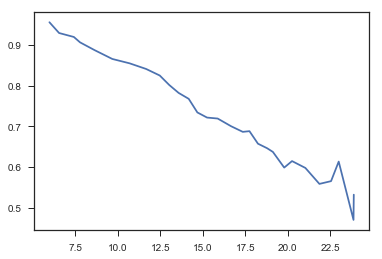

```python
%matplotlib inline

plt.plot(intrate[0:29],defaultrate[0:29])
plt.show()
```

```python
intrate,defaultrate
```

```
(sub_grade
 A1     5.970017
 A2     6.538729
 A3     7.406936
 A4     7.771233
 A5     8.627672
 B1     9.670348
 B2    10.684016
 B3    11.660315
 B4    12.461510
 B5    13.017239
 C1    13.570876
 C2    14.164827
 C3    14.673749
 C4    15.243976
 C5    15.867740
 D1    16.655523
 D2    17.345837
 D3    17.737749
 D4    18.238910
 D5    18.776561
 E1    19.117309
 E2    19.782724
 E3    20.243106
 E4    21.028102
 E5    21.853750
 F1    22.539137
 F2    22.988647
 F3    23.859950
 F4    23.875806
 F5    24.262394
 G1    24.698333
 G2    24.757500
 G3    23.851000
 G4    24.120000
 G5    23.896000
 Name: int_rate, dtype: float64, sub_grade
 A1    0.955605
 A2    0.929143
 A3    0.919470
```

[output cut: 18 more lines]

```
 E2    0.598765
 E3    0.614728
 E4    0.597907
 E5    0.558712
 F1    0.565495
 F2    0.613527
 F3    0.470297
 F4    0.532258
 F5    0.366197
 G1    0.500000
 G2    0.500000
 G3    0.400000
 G4    0.900000
 G5    0.700000
 Name: class_label, dtype: float64)
```